# Исследование объявлений о продаже квартир

В вашем распоряжении данные сервиса Яндекс.Недвижимость — архив объявлений о продаже квартир в Санкт-Петербурге и соседних населённых пунктов за несколько лет. Нужно научиться определять рыночную стоимость объектов недвижимости. Ваша задача — установить параметры. Это позволит построить автоматизированную систему: она отследит аномалии и мошенническую деятельность.

По каждой квартире на продажу доступны два вида данных. Первые вписаны пользователем, вторые — получены автоматически на основе картографических данных. Например, расстояние до центра, аэропорта, ближайшего парка и водоёма.

### Откройте файл с данными и изучите общую информацию.

|  | total_images | last_price | total_area | first_day_exposition | rooms | ceiling_height | floors_total | living_area | floor | is_apartment | studio | open_plan | kitchen_area | balcony | locality_name | airports_nearest | cityCenters_nearest | parks_around3000 | parks_nearest | ponds_around3000 | ponds_nearest | days_exposition |
| --- | --- | --- | --- | --- | --- | --- | --- | --- | --- | --- | --- | --- | --- | --- | --- | --- | --- | --- | --- | --- | --- | --- |
| 0 | 20 | 13000000.0 | 108.00 | 2019-03-07T00:00:00 | 3 | 2.70 | 16.0 | 51.00 | 8 | NaN | False | False | 25.00 | NaN | Санкт-Петербург | 18863.0 | 16028.0 | 1.0 | 482.0 | 2.0 | 755.0 | NaN |
| 1 | 7 | 3350000.0 | 40.40 | 2018-12-04T00:00:00 | 1 | NaN | 11.0 | 18.60 | 1 | NaN | False | False | 11.00 | 2.0 | посёлок Шушары | 12817.0 | 18603.0 | 0.0 | NaN | 0.0 | NaN | 81.0 |
| 2 | 10 | 5196000.0 | 56.00 | 2015-08-20T00:00:00 | 2 | NaN | 5.0 | 34.30 | 4 | NaN | False | False | 8.30 | 0.0 | Санкт-Петербург | 21741.0 | 13933.0 | 1.0 | 90.0 | 2.0 | 574.0 | 558.0 |
| 3 | 0 | 64900000.0 | 159.00 | 2015-07-24T00:00:00 | 3 | NaN | 14.0 | NaN | 9 | NaN | False | False | NaN | 0.0 | Санкт-Петербург | 28098.0 | 6800.0 | 2.0 | 84.0 | 3.0 | 234.0 | 424.0 |
| 4 | 2 | 10000000.0 | 100.00 | 2018-06-19T00:00:00 | 2 | 3.03 | 14.0 | 32.00 | 13 | NaN | False | False | 41.00 | NaN | Санкт-Петербург | 31856.0 | 8098.0 | 2.0 | 112.0 | 1.0 | 48.0 | 121.0 |
| 5 | 10 | 2890000.0 | 30.40 | 2018-09-10T00:00:00 | 1 | NaN | 12.0 | 14.40 | 5 | NaN | False | False | 9.10 | NaN | городской посёлок Янино-1 | NaN | NaN | NaN | NaN | NaN | NaN | 55.0 |
| 6 | 6 | 3700000.0 | 37.30 | 2017-11-02T00:00:00 | 1 | NaN | 26.0 | 10.60 | 6 | NaN | False | False | 14.40 | 1.0 | посёлок Парголово | 52996.0 | 19143.0 | 0.0 | NaN | 0.0 | NaN | 155.0 |
| 7 | 5 | 7915000.0 | 71.60 | 2019-04-18T00:00:00 | 2 | NaN | 24.0 | NaN | 22 | NaN | False | False | 18.90 | 2.0 | Санкт-Петербург | 23982.0 | 11634.0 | 0.0 | NaN | 0.0 | NaN | NaN |
| 8 | 20 | 2900000.0 | 33.16 | 2018-05-23T00:00:00 | 1 | NaN | 27.0 | 15.43 | 26 | NaN | False | False | 8.81 | NaN | посёлок Мурино | NaN | NaN | NaN | NaN | NaN | NaN | 189.0 |
| 9 | 18 | 5400000.0 | 61.00 | 2017-02-26T00:00:00 | 3 | 2.50 | 9.0 | 43.60 | 7 | NaN | False | False | 6.50 | 2.0 | Санкт-Петербург | 50898.0 | 15008.0 | 0.0 | NaN | 0.0 | NaN | 289.0 |

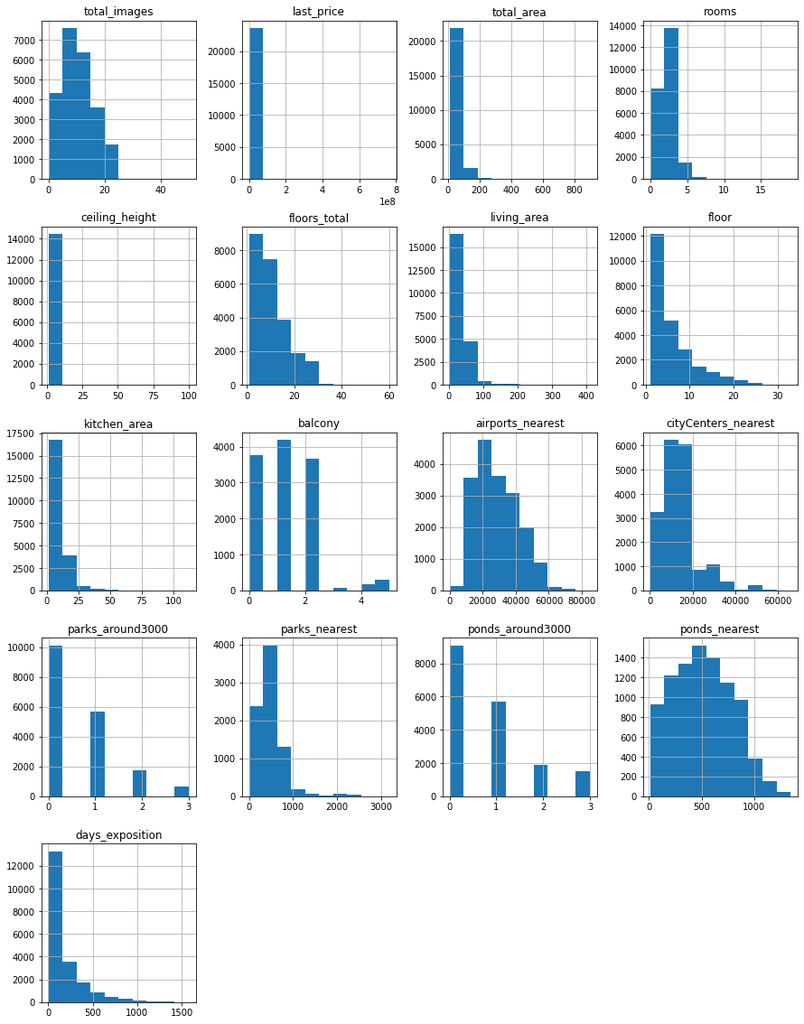

```python
import pandas as pd
import seaborn as sns
import matplotlib.pyplot as plt
pd.set_option('display.max_columns', 50)
data = pd.read_csv('/datasets/real_estate_data.csv', sep ='\t')
data.hist(figsize=(15, 20))
data.head(10)
```

```python
data.describe()
```

|  | total_images | last_price | total_area | rooms | ceiling_height | floors_total | living_area | floor | kitchen_area | balcony | airports_nearest | cityCenters_nearest | parks_around3000 | parks_nearest | ponds_around3000 | ponds_nearest | days_exposition |
| --- | --- | --- | --- | --- | --- | --- | --- | --- | --- | --- | --- | --- | --- | --- | --- | --- | --- |
| count | 23699.000000 | 2.369900e+04 | 23699.000000 | 23699.000000 | 14504.000000 | 23613.000000 | 21796.000000 | 23699.000000 | 21421.000000 | 12180.000000 | 18157.000000 | 18180.000000 | 18181.000000 | 8079.000000 | 18181.000000 | 9110.000000 | 20518.000000 |
| mean | 9.858475 | 6.541549e+06 | 60.348651 | 2.070636 | 2.771499 | 10.673824 | 34.457852 | 5.892358 | 10.569807 | 1.150082 | 28793.672193 | 14191.277833 | 0.611408 | 490.804555 | 0.770255 | 517.980900 | 180.888634 |
| std | 5.682529 | 1.088701e+07 | 35.654083 | 1.078405 | 1.261056 | 6.597173 | 22.030445 | 4.885249 | 5.905438 | 1.071300 | 12630.880622 | 8608.386210 | 0.802074 | 342.317995 | 0.938346 | 277.720643 | 219.727988 |
| min | 0.000000 | 1.219000e+04 | 12.000000 | 0.000000 | 1.000000 | 1.000000 | 2.000000 | 1.000000 | 1.300000 | 0.000000 | 0.000000 | 181.000000 | 0.000000 | 1.000000 | 0.000000 | 13.000000 | 1.000000 |
| 25% | 6.000000 | 3.400000e+06 | 40.000000 | 1.000000 | 2.520000 | 5.000000 | 18.600000 | 2.000000 | 7.000000 | 0.000000 | 18585.000000 | 9238.000000 | 0.000000 | 288.000000 | 0.000000 | 294.000000 | 45.000000 |
| 50% | 9.000000 | 4.650000e+06 | 52.000000 | 2.000000 | 2.650000 | 9.000000 | 30.000000 | 4.000000 | 9.100000 | 1.000000 | 26726.000000 | 13098.500000 | 0.000000 | 455.000000 | 1.000000 | 502.000000 | 95.000000 |
| 75% | 14.000000 | 6.800000e+06 | 69.900000 | 3.000000 | 2.800000 | 16.000000 | 42.300000 | 8.000000 | 12.000000 | 2.000000 | 37273.000000 | 16293.000000 | 1.000000 | 612.000000 | 1.000000 | 729.000000 | 232.000000 |
| max | 50.000000 | 7.630000e+08 | 900.000000 | 19.000000 | 100.000000 | 60.000000 | 409.700000 | 33.000000 | 112.000000 | 5.000000 | 84869.000000 | 65968.000000 | 3.000000 | 3190.000000 | 3.000000 | 1344.000000 | 1580.000000 |

```python
data.info()
```

```
<class 'pandas.core.frame.DataFrame'>
RangeIndex: 23699 entries, 0 to 23698
Data columns (total 22 columns):
 #   Column                Non-Null Count  Dtype
---  ------                --------------  -----
 0   total_images          23699 non-null  int64
 1   last_price            23699 non-null  float64
 2   total_area            23699 non-null  float64
 3   first_day_exposition  23699 non-null  object
 4   rooms                 23699 non-null  int64
 5   ceiling_height        14504 non-null  float64
 6   floors_total          23613 non-null  float64
 7   living_area           21796 non-null  float64
 8   floor                 23699 non-null  int64
 9   is_apartment          2775 non-null   object
 10  studio                23699 non-null  bool
 11  open_plan             23699 non-null  bool
 12  kitchen_area          21421 non-null  float64
 13  balcony               12180 non-null  float64
 14  locality_name         23650 non-null  object
 15  airports_nearest      18157 non-null  float64
 16  cityCenters_nearest   18180 non-null  float64
 17  parks_around3000      18181 non-null  float64
 18  parks_nearest         8079 non-null   float64
 19  ponds_around3000      18181 non-null  float64
 20  ponds_nearest         9110 non-null   float64
 21  days_exposition       20518 non-null  float64
dtypes: bool(2), float64(14), int64(3), object(3)
memory usage: 3.7+ MB
```

### Предобработка данных

```python
data.isna().sum()
```

```
total_images                0
last_price                  0
total_area                  0
first_day_exposition        0
rooms                       0
ceiling_height           9195
floors_total               86
living_area              1903
floor                       0
is_apartment            20924
studio                      0
open_plan                   0
kitchen_area             2278
balcony                 11519
locality_name              49
airports_nearest         5542
cityCenters_nearest      5519
parks_around3000         5518
parks_nearest           15620
ponds_around3000         5518
ponds_nearest           14589
days_exposition          3181
dtype: int64
```

Нужно заменить или избавиться от пропущенных значений. Начнем с изменения типа данных там, где это необходимо.

#### Изменение типа данных

Необходимо преобразовать формат даты в datetime64, а также преобразовать тип данных в столбце 'is_apartment' в 'bool'.

В 'is_apartment', необходимо сначала заполнить пропуски, логично предположить, что пропуски появились в тех случаях, когда объект не являлся апартаментами, поэтому заменим все пропуски на False и преобразуем тип данных.

```python
data['first_day_exposition'] = pd.to_datetime(
    data['first_day_exposition'], format='%Y-%m-%dT%H:%M:%S'
)
data['is_apartment'] = data['is_apartment'].fillna(False)
data['is_apartment'] = data['is_apartment'].astype('bool')
```

#### Заполнение пропусков

Начнем с очевидных пропусков: 1) Балконы: скорее всего, пропуски в этом столбце обусловлены отсутствием балконов.

2) Аналогичная ситуация со стоблцами 'parks_around3000' и 'ponds_around3000'.

3) Площадь кухни: так как в таблице есть квартиры студии, в которых нет кухни, заменяем также все значения в столбце 'kitchen_area' для таких квартир на 0.

Сразу оценим, как изменилось количество пропусков.

```python
data['balcony'] = data['balcony'].fillna(0)

data['parks_around3000'] = data['parks_around3000'].fillna(0)

data['ponds_around3000'] = data['ponds_around3000'].fillna(0)
data.loc[data['studio'] == True, 'kitchen_area'] = 0

columns_isna = ['balcony', 'parks_around3000', 'ponds_around3000', 'kitchen_area']
data[columns_isna].isna().sum()
```

```
balcony                0
parks_around3000       0
ponds_around3000       0
kitchen_area        2129
dtype: int64
```

Теперь отбросим все отсутствующие значения в столбцах 'locality_name', 'kitchen_area', 'living_area' и 'days_exposition'.

Эти параметры точно определить не получится, а неточные данные могут сильно повлиять на результат анализа, т.к. их достаточно много и они будут играть ключевую роль в исследовании.

```python
data=data.dropna(subset=['locality_name', 'kitchen_area', 'living_area', 'days_exposition'])
```

Далее по одному и тому же принципу заполняем пустые строки в столбцах 'floors_total', 'ponds_nearest', 'parks_nearest', 'cityCenters_nearest', 'airports_nearest': заполним их медианными значениями для населенных пунктов.

Для столбца 'floors_total' также добавим условие: если средняя высота домов в этом населенном пункте меньше этажа, на котором расположена квартира, принимаем текущий этаж за последний.

```python
median_locality_floors = data.groupby('locality_name')['floors_total'].median()
def top_floor(row):
    floor = row['floor']
    floors_total = row['floors_total']
    city = row['locality_name']
    if median_locality_floors[city] > floor:
        return median_locality_floors[city]
    else:
        return floor
data.loc[data['floors_total'].isna(), 'floors_total'] = data.loc[data['floors_total'].isna()].apply(top_floor, axis = 1)
```

Для парков и прудов, если по населенному пункту не удалось заполнить пропуск, предполагаем, что парков и прудов поблизости нет, заполняем значением 3100 (так как иначе парк или пруб попал бы в столбец 'ponds_around3000' или 'parks_around3000'

```python
pondsn_medians = data.groupby('locality_name')['ponds_nearest'].median()
for location in data['locality_name'].unique():
    data.loc[(data['locality_name'] == location), 'ponds_nearest'] = \
    data.loc[(data['locality_name'] == location), 'ponds_nearest'].fillna(pondsn_medians[location])
data['ponds_nearest'] = data['ponds_nearest'].fillna(3100)

parksn_medians = data.groupby('locality_name')['parks_nearest'].median()
for location in data['locality_name'].unique():
    data.loc[(data['locality_name'] == location), 'parks_nearest'] = \
    data.loc[(data['locality_name'] == location), 'parks_nearest'].fillna(parksn_medians[location])
data['parks_nearest'] = data['parks_nearest'].fillna(3100)
```

Теперь посмотрим на столбец 'cityCenters_nearest'. Для начала, исправим название столбца.

```python
data = data.rename(columns={'cityCenters_nearest': 'city_centers_nearest'})
сс_medians = data.groupby('locality_name')['city_centers_nearest'].median()
for location in data['locality_name'].unique():
    data.loc[(data['locality_name'] == location), 'city_centers_nearest'] = \
    data.loc[(data['locality_name'] == location), 'city_centers_nearest'].fillna(сс_medians[location])
data.city_centers_nearest.isna().sum()
```

```
3891
```

Пропусков все еще много, посмотрим, есть ли пропуски для Санкт-Петербурга, ведь позже мы будем анализировать этот параметр, а найти точное значение на замену пропущенному не получится.

```python
data_spb = data.query('locality_name == "Санкт-Петербург"')
data_spb.city_centers_nearest.isna().sum()
```

```
0
```

Пропусков нет, остальные пропуски смело заменяем на значение, немного привышающее максимальное, предполагая, что этот параметр пропущен в случае, если город слишком далеко от СПб.

```python
data['city_centers_nearest'] = data['city_centers_nearest'].fillna(70000)
```

Заменим расстояние до аэропорта: максимальное расстояние до аэропорта--84869м, логично предположить, что для оставшихся локаций расстояние до аэропорта не указано, т.к. аэпорот слишком далеко, поэтому заменяем на 200000, т.к. судя по картам, это максимальное расстояние от этих локаций до аэропорта: около 200 км расстояние между Каменногорском или Кузнечным (самыми северными городами Лен. области) и Пулково.

```python
ap_medians = data.groupby('locality_name')['airports_nearest'].median()
for location in data['locality_name'].unique():
    data.loc[(data['locality_name'] == location), 'airports_nearest'] = \
    data.loc[(data['locality_name'] == location), 'airports_nearest'].fillna(ap_medians[location])
data['airports_nearest'] = data['airports_nearest'].fillna(200000)
```

Последний оставшийся параметр: высота потолков. Заменим на медианное значение.

Сразу же оценим результат работы.

```python
data['ceiling_height'] = data['ceiling_height'].fillna(data['ceiling_height'].median())

data = data.reset_index(drop=True)
data.info()
data.isna().sum()
```

```
<class 'pandas.core.frame.DataFrame'>
RangeIndex: 18180 entries, 0 to 18179
Data columns (total 22 columns):
 #   Column                Non-Null Count  Dtype
---  ------                --------------  -----
 0   total_images          18180 non-null  int64
 1   last_price            18180 non-null  float64
 2   total_area            18180 non-null  float64
 3   first_day_exposition  18180 non-null  datetime64[ns]
 4   rooms                 18180 non-null  int64
 5   ceiling_height        18180 non-null  float64
 6   floors_total          18180 non-null  float64
 7   living_area           18180 non-null  float64
 8   floor                 18180 non-null  int64
 9   is_apartment          18180 non-null  bool
 10  studio                18180 non-null  bool
 11  open_plan             18180 non-null  bool
 12  kitchen_area          18180 non-null  float64
 13  balcony               18180 non-null  float64
 14  locality_name         18180 non-null  object
 15  airports_nearest      18180 non-null  float64
 16  city_centers_nearest  18180 non-null  float64
 17  parks_around3000      18180 non-null  float64
 18  parks_nearest         18180 non-null  float64
 19  ponds_around3000      18180 non-null  float64
 20  ponds_nearest         18180 non-null  float64
 21  days_exposition       18180 non-null  float64
dtypes: bool(3), datetime64[ns](1), float64(14), int64(3), object(1)
memory usage: 2.7+ MB
```

```
total_images            0
last_price              0
total_area              0
first_day_exposition    0
rooms                   0
ceiling_height          0
floors_total            0
living_area             0
floor                   0
is_apartment            0
studio                  0
open_plan               0
kitchen_area            0
balcony                 0
locality_name           0
airports_nearest        0
city_centers_nearest    0
parks_around3000        0
parks_nearest           0
ponds_around3000        0
ponds_nearest           0
days_exposition         0
dtype: int64
```

Все пустые значения, замена которых не повлияет на дальнейший анализ заполнены наиболее подходящими значениями

#### Обработка аномальных и редких значений

```python
data['locality_name'].unique()
```

```
array(['посёлок Шушары', 'Санкт-Петербург', 'городской посёлок Янино-1',
       'посёлок Парголово', 'посёлок Мурино', 'Ломоносов', 'Сертолово',
       'Петергоф', 'Пушкин', 'деревня Кудрово', 'Колпино', 'Гатчина',
       'поселок Мурино', 'деревня Фёдоровское', 'Выборг', 'Кронштадт',
       'Кировск', 'деревня Новое Девяткино', 'посёлок Металлострой',
       'посёлок городского типа Сиверский', 'поселок Молодцово',
       'поселок городского типа Кузьмоловский', 'Павловск',
       'деревня Пикколово', 'Всеволожск', 'Кингисепп', 'Сестрорецк',
       'деревня Куттузи', 'деревня Заклинье', 'поселок Торковичи',
       'Красное Село', 'посёлок Понтонный', 'Приозерск', 'село Путилово',
       'Ивангород', 'Сланцы', 'Шлиссельбург', 'Сясьстрой', 'Никольское',
       'Зеленогорск', 'Сосновый Бор', 'поселок Новый Свет',
       'деревня Оржицы', 'деревня Кальтино', 'поселок Романовка',
       'посёлок Бугры', 'поселок Бугры', 'поселок городского типа Рощино',
       'Луга', 'Волосово', 'Отрадное', 'село Павлово', 'поселок Оредеж',
       'посёлок городского типа Красный Бор', 'Кудрово', 'Коммунар',
       'деревня Нурма', 'поселок городского типа Синявино', 'Тосно',
       'посёлок Стрельна', 'посёлок Александровская', 'деревня Лопухинка',
       'поселок Терволово', 'поселок городского типа Советский',
       'посёлок Аннино', 'Кириши', 'посёлок городского типа Токсово',
       'поселок Сельцо', 'посёлок городского типа Вырица',
       'деревня Келози', 'деревня Вартемяги',
       'посёлок городского типа Кузьмоловский', 'посёлок Тельмана',
       'городской поселок Большая Ижора', 'Тихвин', 'деревня Агалатово',
       'посёлок Новогорелово', 'деревня Старая', 'Волхов',
       'поселок городского типа Вырица', 'городской посёлок Новоселье',
       'деревня Большие Колпаны', 'деревня Горбунки', 'деревня Заневка',
       'Приморск', 'деревня Мистолово', 'поселок Зимитицы',
       'поселок Барышево', 'деревня Разметелево',
       'поселок городского типа имени Свердлова', 'деревня Пеники',
       'поселок Рябово', 'деревня Пудомяги', 'деревня Бегуницы',
       'городской посёлок Мга', 'деревня Колтуши', 'Бокситогорск',
       'посёлок городского типа Рощино', 'деревня Малое Карлино',
       'посёлок Песочный', 'деревня Аро', 'поселок Ильичёво',
       'посёлок городского типа Тайцы', 'деревня Малое Верево',
       'Подпорожье', 'поселок станции Вещево', 'деревня Калитино',
       'посёлок городского типа Ульяновка',
       'поселок городского типа Дубровка', 'поселок Войсковицы',
       'посёлок городского типа имени Свердлова', 'Новая Ладога',
       'посёлок Ропша', 'поселок Первомайское',
```

[output cut: 67 more lines]

```
       'деревня Глинка', 'поселок городского типа Токсово',
       'деревня Ваганово', 'поселок Пушное', 'садовое товарищество Садко',
       'посёлок Петровское', 'деревня Выскатка', 'посёлок станции Свирь',
       'деревня Кисельня', 'посёлок Старая Малукса', 'поселок Калитино',
       'посёлок станции Громово', 'посёлок Высокоключевой',
       'садовое товарищество Приладожский',
       'посёлок Пансионат Зелёный Бор', 'деревня Ненимяки',
       'поселок Пансионат Зелёный Бор', 'поселок Громово',
       'посёлок городского типа Важины', 'деревня Рапполово',
       'деревня Пустынка', 'посёлок Усть-Ижора', 'деревня Лупполово',
       'деревня Большое Рейзино', 'деревня Малая Романовка',
       'деревня Суоранда', 'поселок Дружноселье', 'село Паша',
       'поселок Володарское', 'деревня Нижняя',
       'коттеджный посёлок Лесное', 'деревня Тихковицы',
       'деревня Борисова Грива', 'деревня Рабитицы'], dtype=object)
```

Будем убирать типы населенных пунктов (поселок/деревня/товарищество и т.д.)

```python
def func_name(locality_name):
    str_only_name=[]
    for slovo in locality_name.split():
        for c in slovo:
            if c.isupper():
                str_only_name.append(slovo)
                break
    return ' '.join(str_only_name)
data['locality_only_name'] = data['locality_name'].apply(func_name)
data['locality_only_name'].unique()
```

```
array(['Шушары', 'Санкт-Петербург', 'Янино-1', 'Парголово', 'Мурино',
       'Ломоносов', 'Сертолово', 'Петергоф', 'Пушкин', 'Кудрово',
       'Колпино', 'Гатчина', 'Фёдоровское', 'Выборг', 'Кронштадт',
       'Кировск', 'Новое Девяткино', 'Металлострой', 'Сиверский',
       'Молодцово', 'Кузьмоловский', 'Павловск', 'Пикколово',
       'Всеволожск', 'Кингисепп', 'Сестрорецк', 'Куттузи', 'Заклинье',
       'Торковичи', 'Красное Село', 'Понтонный', 'Приозерск', 'Путилово',
       'Ивангород', 'Сланцы', 'Шлиссельбург', 'Сясьстрой', 'Никольское',
       'Зеленогорск', 'Сосновый Бор', 'Новый Свет', 'Оржицы', 'Кальтино',
       'Романовка', 'Бугры', 'Рощино', 'Луга', 'Волосово', 'Отрадное',
       'Павлово', 'Оредеж', 'Красный Бор', 'Коммунар', 'Нурма',
       'Синявино', 'Тосно', 'Стрельна', 'Александровская', 'Лопухинка',
       'Терволово', 'Советский', 'Аннино', 'Кириши', 'Токсово', 'Сельцо',
       'Вырица', 'Келози', 'Вартемяги', 'Тельмана', 'Большая Ижора',
       'Тихвин', 'Агалатово', 'Новогорелово', 'Старая', 'Волхов',
       'Новоселье', 'Большие Колпаны', 'Горбунки', 'Заневка', 'Приморск',
       'Мистолово', 'Зимитицы', 'Барышево', 'Разметелево', 'Свердлова',
       'Пеники', 'Рябово', 'Пудомяги', 'Бегуницы', 'Мга', 'Колтуши',
       'Бокситогорск', 'Малое Карлино', 'Песочный', 'Аро', 'Ильичёво',
       'Тайцы', 'Малое Верево', 'Подпорожье', 'Вещево', 'Калитино',
       'Ульяновка', 'Дубровка', 'Войсковицы', 'Новая Ладога', 'Ропша',
       'Первомайское', 'Приладожский', 'Щеглово', 'Гаврилово',
       'Лодейное Поле', 'Лебяжье', 'Кузьмолово', 'Малые Колпаны',
       'Лаголово', 'Назия', 'Углово', 'Низино', 'Старая Малукса', 'Рахья',
       'Победа', 'Старые Бегуницы', 'Морозова', 'Сапёрный', 'Семрино',
       'Глажево', 'Кобринское', 'Запорожское', 'Елизаветино', 'Юкки',
       'Приветнинское', 'Мануйлово', 'Поляны', 'Лесколово', 'Белогорка',
       'Цвылёво', 'Мельниково', 'Плодовое', 'Гостилицы', 'Пудость',
       'Светогорск', 'Любань', 'Селезнёво', 'Каменногорск', 'Парицы',
       'Жилпосёлок', 'Стеклянный', 'Кузнечное', 'Русско-Высоцкое',
       'Форносово', 'Житково', 'Виллози', 'Шпаньково', 'Кипень',
       'Молодёжное', 'Мины', 'Сосново', 'Возрождение', 'Старосиверская',
       'Кикерино', 'Старое Хинколово', 'Пригородный', 'Торфяное',
       'Пикалёво', 'Будогощь', 'Суходолье', 'Красная Долина', 'Хапо-Ое',
       'Дружная Горка', 'Извара', 'Гарболово', 'Лисий Нос', 'Рождествено',
       'Войскорово', 'Сяськелево', 'Камышовка', 'Лесная Поляна',
       'Жилгородок', 'Ялгино', 'Батово', 'Новый Учхоз', 'Гончарово',
       'Сапёрное', 'Платформа', 'Каложицы', 'Фалилеево', 'Пельгора',
       'Лесогорский', 'Белоостров', 'Алексеевка', 'Глебычево',
       'Петровское', 'Никольский', 'Кингисеппский', 'Ушаки', 'Старополье',
       'Лампово', 'Торосово', 'Ефимовский', 'Старая Пустошь', 'Коммунары',
       'Починок', 'Репино', 'Усть-Луга', 'Мичуринское', 'Гладкое',
       'Тёсово-4', 'Бор', 'Серебрянский', 'Разбегаево', 'Кобралово',
       'Кондратьево', 'Копорье', 'Реброво', 'Яльгелево', 'Большая Вруда',
       'Семиозерье', 'Совхозный', 'Суйда', 'Нижние Осельки', 'Перово',
       'Заводской', 'Высоцк', 'Шум', 'Большая Пустомержа',
       'Кивеннапа Север', 'Коробицыно', 'Ромашки', 'Каськово', 'Куровицы',
       'Сумино', 'Ям-Тесово', 'Терпилицы', 'Вознесенье', 'Глинка',
       'Ваганово', 'Пушное', 'Садко', 'Выскатка', 'Свирь', 'Кисельня',
       'Громово', 'Высокоключевой', 'Пансионат Зелёный Бор', 'Ненимяки',
       'Важины', 'Рапполово', 'Пустынка', 'Усть-Ижора', 'Лупполово',
       'Большое Рейзино', 'Малая Романовка', 'Суоранда', 'Дружноселье',
       'Паша', 'Володарское', 'Нижняя', 'Лесное', 'Тихковицы',
       'Борисова Грива', 'Рабитицы'], dtype=object)
```

Неявные дубликаты убраны, теперь посмотрим поближе на высоту потолков.

```python
data['ceiling_height'].unique()
```

```
array([  2.65,   3.03,   2.5 ,   2.67,   2.56,   3.05,   2.75,   2.7 ,
         2.6 ,   2.9 ,   2.8 ,   2.55,   3.  ,   3.2 ,   3.25,   3.45,
         2.77,   2.85,   2.64,   2.57,   4.15,   3.3 ,   2.47,   2.84,
         3.1 ,   3.4 ,   3.5 ,   2.72,   2.54,   2.51,   2.78,   2.76,
         2.58,   3.7 ,   2.52,   5.2 ,   2.87,   2.66,   2.59,   2.  ,
         2.92,   3.11,   3.13,   3.8 ,   3.15,   3.6 ,   3.55,   3.16,
         2.53,   2.73,   2.96,   2.46,   2.74,   2.45,   4.  ,   2.95,
         4.06,   2.79,   3.82,   3.53,   2.83,   4.7 ,   3.38,   3.65,
         3.9 ,   2.71,   3.35,   2.3 ,   3.01,   2.48,   2.62,   3.57,
         2.82,   3.98,   3.12,   2.63,   3.83,   3.95,   2.4 ,   2.88,
         3.87,   3.66,   3.85,   3.86,   4.19,   3.24,   4.8 ,   4.2 ,
         3.75,   4.5 ,   3.68,   8.  ,   2.94,   3.26,   3.34,   2.81,
         3.07,   3.44,   2.97,   4.37,   2.68,   3.22,   3.27,  25.  ,
         3.52,   2.93,   3.46,  24.  ,   3.47,  27.  ,   3.63,   3.33,
         3.32,  26.  ,   1.2 ,   3.18,   8.3 ,   4.1 ,   2.86,   3.08,
         3.17,   4.4 ,   3.67,   3.04,   4.45,   3.84,   3.09,   3.28,
         3.02,   3.21,   3.43,   3.23,   3.54,   2.61,   3.06,   3.39,
         4.65,   3.56,   2.2 ,   3.51,   3.93,   3.42,   3.49,  14.  ,
         3.14,   3.78,   3.31,   3.88,   1.75,   4.25,   3.29,   2.25,
         3.37,   3.76,   6.  ,  22.6 ,   2.89,   5.8 ,  27.5 ,   2.69,
         2.49,   4.9 ,   3.48,   2.98,   1.  , 100.  ,   3.59,   2.91,
         3.36])
```

Со значениями 20-35м логично будет заменить эти значения на 2.0-3.5.

Сегодня минимальной нормой в России считается высота потолка 2,4 метра. Необходимо построить график и сделать срезы, чтобы решить, от каких значений можно избавиться.

```python
data.loc[data['ceiling_height'] >= 20, 'ceiling_height'] = data.loc[data['ceiling_height'] >= 20, 'ceiling_height']/10
```

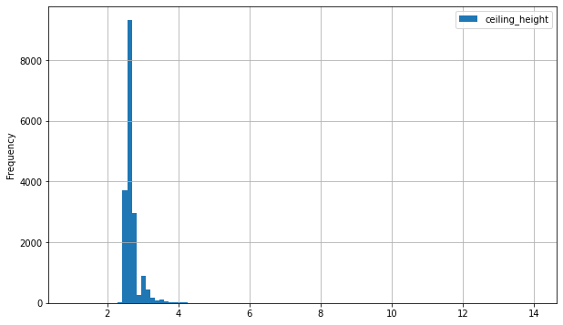

```python
data.plot(y = 'ceiling_height', kind = 'hist', bins = 100, grid=True, figsize = (10,6))
```

```python
data.query('ceiling_height<2.4')
```

|  | total_images | last_price | total_area | first_day_exposition | rooms | ceiling_height | floors_total | living_area | floor | is_apartment | studio | open_plan | kitchen_area | balcony | locality_name | airports_nearest | city_centers_nearest | parks_around3000 | parks_nearest | ponds_around3000 | ponds_nearest | days_exposition | locality_only_name |
| --- | --- | --- | --- | --- | --- | --- | --- | --- | --- | --- | --- | --- | --- | --- | --- | --- | --- | --- | --- | --- | --- | --- | --- |
| 431 | 11 | 2999000.0 | 33.50 | 2017-03-30 | 1 | 2.00 | 15.0 | 17.500000 | 6 | False | False | False | 6.50 | 0.0 | Санкт-Петербург | 33972.0 | 11746.0 | 1.0 | 520.0 | 1.0 | 949.0 | 270.0 | Санкт-Петербург |
| 1236 | 4 | 4100000.0 | 45.60 | 2016-01-13 | 2 | 2.30 | 9.0 | 28.400000 | 8 | False | False | False | 7.00 | 2.0 | Санкт-Петербург | 49152.0 | 14977.0 | 1.0 | 489.0 | 1.0 | 525.0 | 329.0 | Санкт-Петербург |
| 3219 | 1 | 2120000.0 | 35.43 | 2017-12-18 | 1 | 2.00 | 18.0 | 16.600000 | 9 | False | False | False | 8.80 | 2.0 | Тосно | 200000.0 | 70000.0 | 0.0 | 3100.0 | 0.0 | 3100.0 | 36.0 | Тосно |
| 4214 | 17 | 2200000.0 | 56.00 | 2018-04-02 | 2 | 2.30 | 5.0 | 45.000000 | 1 | False | False | False | 9.00 | 2.0 | Сясьстрой | 200000.0 | 70000.0 | 0.0 | 3100.0 | 0.0 | 3100.0 | 55.0 | Сясьстрой |
| 4373 | 5 | 1500000.0 | 42.80 | 2017-08-14 | 2 | 1.20 | 2.0 | 27.500000 | 1 | False | False | False | 5.20 | 0.0 | городской посёлок Мга | 200000.0 | 70000.0 | 0.0 | 3100.0 | 0.0 | 3100.0 | 248.0 | Мга |
| 8730 | 4 | 3300000.0 | 36.00 | 2017-06-18 | 1 | 2.00 | 17.0 | 15.200000 | 12 | False | False | False | 10.10 | 0.0 | посёлок Металлострой | 25268.0 | 26980.0 | 0.0 | 3100.0 | 0.0 | 3100.0 | 53.0 | Металлострой |
| 9818 | 2 | 1400000.0 | 22.50 | 2017-09-21 | 1 | 2.20 | 2.0 | 18.000000 | 2 | False | False | False | 4.50 | 1.0 | село Копорье | 200000.0 | 70000.0 | 0.0 | 3100.0 | 0.0 | 3100.0 | 45.0 | Копорье |
| 12996 | 0 | 1500000.0 | 33.00 | 2018-10-03 | 1 | 2.00 | 5.0 | 20.000000 | 5 | False | False | False | 6.00 | 0.0 | Выборг | 200000.0 | 70000.0 | 0.0 | 3100.0 | 0.0 | 3100.0 | 6.0 | Выборг |
| 13035 | 5 | 4100000.0 | 40.00 | 2017-10-17 | 1 | 1.75 | 37.0 | 17.400000 | 5 | False | False | False | 8.34 | 0.0 | Санкт-Петербург | 18732.0 | 20444.0 | 0.0 | 459.0 | 3.0 | 80.0 | 71.0 | Санкт-Петербург |
| 13661 | 20 | 2300000.0 | 54.30 | 2018-06-28 | 3 | 2.30 | 5.0 | 39.000000 | 2 | False | False | False | 5.30 | 1.0 | деревня Бегуницы | 200000.0 | 70000.0 | 0.0 | 3100.0 | 0.0 | 3100.0 | 189.0 | Бегуницы |
| 13683 | 1 | 2300000.0 | 58.60 | 2016-05-12 | 3 | 2.25 | 5.0 | 44.100002 | 3 | False | False | False | 5.50 | 1.0 | деревня Бегуницы | 200000.0 | 70000.0 | 0.0 | 3100.0 | 0.0 | 3100.0 | 45.0 | Бегуницы |
| 14673 | 7 | 2700000.0 | 56.00 | 2018-02-04 | 3 | 2.00 | 5.0 | 46.000000 | 1 | False | False | False | 6.00 | 0.0 | Выборг | 200000.0 | 70000.0 | 0.0 | 3100.0 | 0.0 | 3100.0 | 282.0 | Выборг |
| 15742 | 12 | 5950000.0 | 60.00 | 2018-02-19 | 2 | 2.26 | 14.0 | 35.000000 | 11 | False | False | False | 13.00 | 1.0 | Санкт-Петербург | 27028.0 | 12570.0 | 0.0 | 459.0 | 0.0 | 510.0 | 40.0 | Санкт-Петербург |
| 15752 | 9 | 3600000.0 | 38.00 | 2018-07-05 | 1 | 2.00 | 12.0 | 15.000000 | 9 | False | False | False | 11.80 | 1.0 | Кудрово | 200000.0 | 70000.0 | 0.0 | 3100.0 | 0.0 | 3100.0 | 62.0 | Кудрово |
| 17327 | 16 | 6000000.0 | 55.00 | 2018-10-31 | 2 | 1.00 | 12.0 | 32.400000 | 7 | False | False | False | 10.00 | 0.0 | Санкт-Петербург | 33053.0 | 14217.0 | 2.0 | 293.0 | 2.0 | 289.0 | 13.0 | Санкт-Петербург |
| 18033 | 7 | 1600000.0 | 54.00 | 2016-12-26 | 2 | 2.30 | 1.0 | 33.000000 | 1 | False | False | False | 3.50 | 0.0 | Высоцк | 200000.0 | 70000.0 | 0.0 | 3100.0 | 0.0 | 3100.0 | 281.0 | Высоцк |

```python
data.loc[data['ceiling_height'] < 2.4, 'ceiling_height'] =  None
data=data.dropna(subset=['ceiling_height'])
```

Теперь посмотрим как обстоят дела с потолками больше 4м.

```python
morethan4 = data.query('ceiling_height>4')
morethan4
```

|  | total_images | last_price | total_area | first_day_exposition | rooms | ceiling_height | floors_total | living_area | floor | is_apartment | studio | open_plan | kitchen_area | balcony | locality_name | airports_nearest | city_centers_nearest | parks_around3000 | parks_nearest | ponds_around3000 | ponds_nearest | days_exposition | locality_only_name |
| --- | --- | --- | --- | --- | --- | --- | --- | --- | --- | --- | --- | --- | --- | --- | --- | --- | --- | --- | --- | --- | --- | --- | --- |
| 124 | 1 | 8200000.0 | 80.0 | 2018-11-06 | 3 | 4.15 | 3.0 | 44.2 | 2 | False | False | False | 12.2 | 0.0 | Санкт-Петербург | 20562.0 | 3167.0 | 2.0 | 344.0 | 1.0 | 838.0 | 38.0 | Санкт-Петербург |
| 359 | 15 | 66571000.0 | 280.3 | 2015-06-11 | 6 | 5.20 | 8.0 | 159.5 | 7 | False | False | False | 21.1 | 0.0 | Санкт-Петербург | 26316.0 | 6655.0 | 3.0 | 187.0 | 1.0 | 616.0 | 578.0 | Санкт-Петербург |
| 888 | 20 | 6695000.0 | 36.9 | 2018-09-28 | 1 | 4.06 | 5.0 | 22.0 | 2 | False | False | False | 7.2 | 0.0 | Санкт-Петербург | 21725.0 | 2990.0 | 1.0 | 596.0 | 1.0 | 866.0 | 110.0 | Санкт-Петербург |
| 1020 | 14 | 120000000.0 | 280.0 | 2018-07-12 | 5 | 4.70 | 4.0 | 162.0 | 3 | False | False | False | 30.0 | 0.0 | Санкт-Петербург | 24680.0 | 4247.0 | 1.0 | 464.0 | 3.0 | 339.0 | 225.0 | Санкт-Петербург |
| 2031 | 17 | 4850000.0 | 59.7 | 2017-11-18 | 3 | 4.19 | 5.0 | 46.3 | 4 | False | False | False | 6.4 | 1.0 | Санкт-Петербург | 42964.0 | 15468.0 | 0.0 | 459.0 | 0.0 | 510.0 | 60.0 | Санкт-Петербург |
| 2157 | 7 | 14950000.0 | 50.0 | 2016-03-06 | 2 | 4.80 | 3.0 | 30.0 | 2 | False | False | False | 10.0 | 0.0 | Санкт-Петербург | 24433.0 | 1725.0 | 1.0 | 589.0 | 3.0 | 161.0 | 160.0 | Санкт-Петербург |
| 2187 | 15 | 11990000.0 | 104.0 | 2018-03-13 | 3 | 4.20 | 3.0 | 66.0 | 2 | False | False | False | 15.0 | 0.0 | Санкт-Петербург | 22393.0 | 3884.0 | 0.0 | 459.0 | 0.0 | 510.0 | 350.0 | Санкт-Петербург |
| 2304 | 11 | 4450000.0 | 36.0 | 2017-12-12 | 1 | 4.19 | 5.0 | 18.0 | 1 | False | False | False | 8.0 | 0.0 | Санкт-Петербург | 24689.0 | 4256.0 | 1.0 | 1077.0 | 3.0 | 690.0 | 78.0 | Санкт-Петербург |
| 2352 | 13 | 6600000.0 | 95.0 | 2018-09-08 | 2 | 4.50 | 7.0 | 45.0 | 7 | True | False | False | 25.0 | 2.0 | Выборг | 200000.0 | 70000.0 | 0.0 | 3100.0 | 0.0 | 3100.0 | 96.0 | Выборг |
| 2665 | 3 | 1400000.0 | 30.0 | 2018-03-16 | 1 | 8.00 | 5.0 | 15.3 | 2 | False | False | False | 7.3 | 0.0 | деревня Нурма | 200000.0 | 70000.0 | 0.0 | 3100.0 | 0.0 | 3100.0 | 125.0 | Нурма |
| 3210 | 9 | 8250000.0 | 84.2 | 2017-11-29 | 2 | 4.37 | 3.0 | 52.0 | 3 | False | False | False | 15.0 | 0.0 | Санкт-Петербург | 23959.0 | 4527.0 | 1.0 | 342.0 | 0.0 | 510.0 | 17.0 | Санкт-Петербург |
| 4492 | 20 | 5650000.0 | 45.0 | 2018-08-15 | 1 | 8.30 | 16.0 | 19.3 | 14 | False | False | False | 8.3 | 1.0 | Санкт-Петербург | 13069.0 | 10763.0 | 0.0 | 459.0 | 1.0 | 613.0 | 14.0 | Санкт-Петербург |
| 4688 | 13 | 40000000.0 | 65.3 | 2017-07-13 | 2 | 4.10 | 5.0 | 45.0 | 2 | False | False | False | 12.0 | 2.0 | Санкт-Петербург | 23308.0 | 2380.0 | 1.0 | 473.0 | 1.0 | 283.0 | 497.0 | Санкт-Петербург |
| 5073 | 17 | 3100000.0 | 35.2 | 2018-08-23 | 1 | 4.20 | 6.0 | 17.0 | 6 | False | False | False | 10.0 | 1.0 | Всеволожск | 200000.0 | 70000.0 | 0.0 | 3100.0 | 0.0 | 3100.0 | 15.0 | Всеволожск |
| 5157 | 10 | 55000000.0 | 280.0 | 2018-03-22 | 7 | 4.40 | 6.0 | 195.0 | 5 | False | False | False | 22.0 | 1.0 | Санкт-Петербург | 32534.0 | 4725.0 | 0.0 | 459.0 | 2.0 | 594.0 | 406.0 | Санкт-Петербург |
| 5215 | 15 | 7500000.0 | 69.0 | 2017-02-15 | 2 | 4.50 | 3.0 | 64.0 | 3 | False | False | False | 25.0 | 0.0 | Санкт-Петербург | 40326.0 | 15610.0 | 0.0 | 459.0 | 2.0 | 852.0 | 427.0 | Санкт-Петербург |
| 5289 | 14 | 15500000.0 | 107.0 | 2017-11-21 | 3 | 4.20 | 6.0 | 60.0 | 3 | False | False | False | 25.0 | 0.0 | Санкт-Петербург | 22148.0 | 4291.0 | 1.0 | 679.0 | 0.0 | 510.0 | 289.0 | Санкт-Петербург |
| 5584 | 4 | 18000000.0 | 127.0 | 2016-05-17 | 3 | 4.20 | 3.0 | 83.8 | 1 | False | False | False | 11.4 | 0.0 | Санкт-Петербург | 24899.0 | 4785.0 | 0.0 | 459.0 | 1.0 | 603.0 | 970.0 | Санкт-Петербург |
| 5779 | 16 | 43500000.0 | 245.8 | 2015-12-17 | 3 | 4.45 | 7.0 | 170.8 | 7 | True | False | False | 25.0 | 1.0 | Санкт-Петербург | 26766.0 | 5735.0 | 2.0 | 110.0 | 0.0 | 510.0 | 1067.0 | Санкт-Петербург |
| 6162 | 20 | 84000000.0 | 507.0 | 2015-12-17 | 5 | 4.45 | 7.0 | 301.5 | 7 | True | False | False | 45.5 | 1.0 | Санкт-Петербург | 26766.0 | 5735.0 | 2.0 | 110.0 | 0.0 | 510.0 | 1078.0 | Санкт-Петербург |
| 7536 | 13 | 37900000.0 | 220.0 | 2017-10-23 | 6 | 4.50 | 5.0 | 148.0 | 5 | False | False | False | 21.0 | 1.0 | Санкт-Петербург | 32534.0 | 4725.0 | 0.0 | 459.0 | 2.0 | 594.0 | 364.0 | Санкт-Петербург |
| 7823 | 14 | 11500000.0 | 85.6 | 2018-12-18 | 3 | 4.50 | 3.0 | 63.0 | 3 | False | False | False | 12.0 | 0.0 | Санкт-Петербург | 51944.0 | 16170.0 | 0.0 | 459.0 | 2.0 | 389.0 | 34.0 | Санкт-Петербург |
| 8564 | 12 | 10300000.0 | 80.5 | 2018-02-01 | 3 | 4.20 | 5.0 | 37.0 | 5 | False | False | False | 34.0 | 1.0 | Пушкин | 19907.0 | 32061.0 | 0.0 | 394.5 | 0.0 | 405.0 | 105.0 | Пушкин |
| 8647 | 19 | 9998000.0 | 65.6 | 2017-08-15 | 2 | 4.10 | 4.0 | 33.0 | 3 | False | False | False | 9.0 | 0.0 | Санкт-Петербург | 24437.0 | 4269.0 | 0.0 | 459.0 | 1.0 | 682.0 | 589.0 | Санкт-Петербург |
| 8964 | 1 | 8500000.0 | 135.0 | 2016-07-03 | 3 | 4.40 | 5.0 | 61.5 | 3 | False | False | False | 16.0 | 0.0 | Санкт-Петербург | 24844.0 | 4840.0 | 0.0 | 459.0 | 1.0 | 787.0 | 257.0 | Санкт-Петербург |
| 9535 | 20 | 91500000.0 | 495.0 | 2017-06-19 | 7 | 4.65 | 7.0 | 347.5 | 7 | False | False | False | 25.0 | 0.0 | Санкт-Петербург | 26766.0 | 5735.0 | 2.0 | 110.0 | 0.0 | 510.0 | 14.0 | Санкт-Петербург |
| 11585 | 19 | 5600000.0 | 56.4 | 2018-05-11 | 2 | 14.00 | 14.0 | 32.4 | 5 | False | False | False | 9.1 | 2.0 | Санкт-Петербург | 14814.0 | 13610.0 | 0.0 | 459.0 | 0.0 | 510.0 | 315.0 | Санкт-Петербург |
| 12108 | 14 | 5600000.0 | 67.0 | 2016-11-11 | 3 | 8.00 | 16.0 | 41.0 | 1 | False | False | False | 8.0 | 0.0 | Санкт-Петербург | 32691.0 | 11035.0 | 1.0 | 723.0 | 0.0 | 510.0 | 474.0 | Санкт-Петербург |
| 13149 | 20 | 11500000.0 | 57.4 | 2017-07-24 | 1 | 4.25 | 6.0 | 37.5 | 3 | False | False | False | 5.6 | 0.0 | Санкт-Петербург | 21990.0 | 392.0 | 3.0 | 207.0 | 2.0 | 617.0 | 451.0 | Санкт-Петербург |
| 14631 | 8 | 23750000.0 | 124.0 | 2016-11-25 | 3 | 4.20 | 6.0 | 67.0 | 2 | False | False | False | 26.0 | 0.0 | Санкт-Петербург | 23568.0 | 1898.0 | 3.0 | 515.0 | 3.0 | 264.0 | 775.0 | Санкт-Петербург |
| 14708 | 10 | 8650000.0 | 87.7 | 2017-07-18 | 2 | 4.70 | 26.0 | 57.4 | 26 | False | False | False | 25.0 | 2.0 | Санкт-Петербург | 40648.0 | 9888.0 | 1.0 | 1248.0 | 0.0 | 510.0 | 15.0 | Санкт-Петербург |
| 15556 | 17 | 119000000.0 | 187.6 | 2017-07-10 | 4 | 6.00 | 7.0 | 147.0 | 7 | False | False | False | 15.6 | 0.0 | Санкт-Петербург | 26902.0 | 5605.0 | 3.0 | 484.0 | 1.0 | 305.0 | 259.0 | Санкт-Петербург |
| 16290 | 0 | 8200000.0 | 71.0 | 2017-07-21 | 0 | 5.80 | 5.0 | 68.0 | 5 | False | True | False | 0.0 | 0.0 | Санкт-Петербург | 20170.0 | 1261.0 | 2.0 | 295.0 | 3.0 | 366.0 | 30.0 | Санкт-Петербург |
| 16828 | 10 | 115490000.0 | 235.0 | 2017-04-09 | 5 | 4.90 | 5.0 | 140.0 | 5 | False | False | False | 50.0 | 0.0 | Санкт-Петербург | 22777.0 | 1328.0 | 3.0 | 652.0 | 3.0 | 253.0 | 351.0 | Санкт-Петербург |
| 16924 | 2 | 8550000.0 | 75.1 | 2017-08-09 | 3 | 4.20 | 6.0 | 52.5 | 3 | False | False | False | 8.0 | 0.0 | Санкт-Петербург | 23060.0 | 2602.0 | 1.0 | 584.0 | 0.0 | 510.0 | 477.0 | Санкт-Петербург |
| 17254 | 7 | 91075000.0 | 491.0 | 2017-05-27 | 5 | 4.20 | 9.0 | 274.0 | 9 | False | False | False | 45.0 | 0.0 | Санкт-Петербург | 25525.0 | 5845.0 | 2.0 | 116.0 | 0.0 | 510.0 | 115.0 | Санкт-Петербург |
| 17547 | 0 | 15000000.0 | 25.0 | 2018-07-25 | 1 | 10.00 | 5.0 | 14.0 | 5 | True | False | False | 11.0 | 5.0 | Санкт-Петербург | 34963.0 | 8283.0 | 1.0 | 223.0 | 3.0 | 30.0 | 19.0 | Санкт-Петербург |

```python
data.loc[data['ceiling_height'] > 4, 'ceiling_height'] =  None
data=data.dropna(subset=['ceiling_height'])
data = data.reset_index(drop=True)
data['ceiling_height'].describe()
```

```
count    18127.000000
mean         2.688433
std          0.196742
min          2.400000
25%          2.600000
50%          2.650000
75%          2.700000
max          4.000000
Name: ceiling_height, dtype: float64
```

```
count    18127.000000
mean         2.688433
std          0.196742
min          2.400000
25%          2.600000
50%          2.650000
75%          2.700000
max          4.000000
Name: ceiling_height, dtype: float64
```

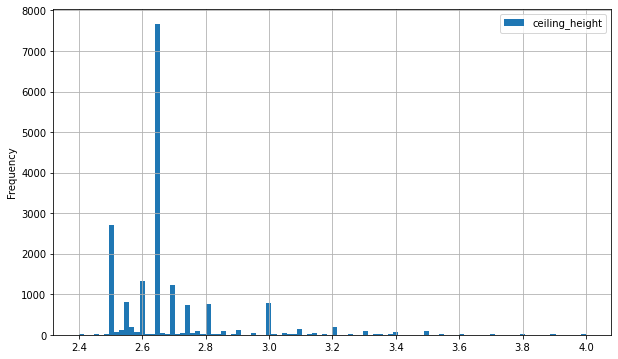

```python
data.plot(y = 'ceiling_height', kind = 'hist', bins = 100, grid=True, figsize = (10,6))
data['ceiling_height'].describe()
```

Такие данные выглядят правдоподобно.

Проанализируем другие столбцы с неправдоподобными значениями. Для этого я нашла в интернете некоторые нормы для жилых помещений в целом и многоквартирных домов в СПб в частности:

Согласно действующим СНиПам, минимальная площадь комнаты должна быть не менее 8 квадратных метров (п. 5.3 СП 5.413330.2011).

```python
data.query('living_area<8')
```

|  | total_images | last_price | total_area | first_day_exposition | rooms | ceiling_height | floors_total | living_area | floor | is_apartment | studio | open_plan | kitchen_area | balcony | locality_name | airports_nearest | city_centers_nearest | parks_around3000 | parks_nearest | ponds_around3000 | ponds_nearest | days_exposition | locality_only_name |
| --- | --- | --- | --- | --- | --- | --- | --- | --- | --- | --- | --- | --- | --- | --- | --- | --- | --- | --- | --- | --- | --- | --- | --- |
| 2472 | 7 | 4440000.0 | 41.0 | 2017-07-02 | 1 | 2.65 | 17.0 | 3.0 | 17 | False | False | False | 11.0 | 0.0 | Санкт-Петербург | 19272.0 | 13073.0 | 0.0 | 459.0 | 0.0 | 510.0 | 216.0 | Санкт-Петербург |
| 10667 | 20 | 6350000.0 | 52.0 | 2018-02-06 | 2 | 3.00 | 6.0 | 2.0 | 2 | False | False | False | 9.0 | 0.0 | Санкт-Петербург | 32453.0 | 6521.0 | 0.0 | 459.0 | 1.0 | 1012.0 | 91.0 | Санкт-Петербург |
| 12604 | 13 | 3799000.0 | 31.0 | 2018-04-12 | 1 | 2.60 | 5.0 | 6.0 | 1 | False | False | False | 17.0 | 0.0 | Санкт-Петербург | 32177.0 | 4826.0 | 1.0 | 430.0 | 0.0 | 510.0 | 168.0 | Санкт-Петербург |
| 13485 | 11 | 2680000.0 | 22.0 | 2018-08-11 | 0 | 2.65 | 25.0 | 5.0 | 8 | False | True | False | 0.0 | 2.0 | Санкт-Петербург | 22735.0 | 11618.0 | 1.0 | 835.0 | 1.0 | 652.0 | 70.0 | Санкт-Петербург |
| 14753 | 19 | 4050000.0 | 33.0 | 2018-10-15 | 1 | 2.50 | 22.0 | 6.5 | 21 | False | False | False | 18.0 | 0.0 | Санкт-Петербург | 9258.0 | 10592.0 | 1.0 | 458.0 | 0.0 | 510.0 | 44.0 | Санкт-Петербург |
| 16657 | 0 | 2330000.0 | 23.0 | 2018-01-01 | 0 | 2.65 | 24.0 | 2.0 | 22 | False | True | False | 0.0 | 0.0 | посёлок Мурино | 200000.0 | 70000.0 | 0.0 | 3100.0 | 0.0 | 3100.0 | 66.0 | Мурино |
| 16796 | 15 | 6100000.0 | 77.6 | 2019-02-28 | 4 | 2.50 | 9.0 | 5.4 | 1 | False | False | False | 9.8 | 0.0 | Санкт-Петербург | 29338.0 | 11270.0 | 1.0 | 584.0 | 0.0 | 510.0 | 33.0 | Санкт-Петербург |
| 18034 | 14 | 64990000.0 | 139.0 | 2015-11-24 | 3 | 3.00 | 8.0 | 3.0 | 8 | False | False | False | 16.0 | 1.0 | Санкт-Петербург | 33255.0 | 5975.0 | 1.0 | 630.0 | 3.0 | 100.0 | 280.0 | Санкт-Петербург |

Ни одно из этих помещений также не является апартаментами, хотя площади квартир и выглядят правдоподобно, мы убираем подозрительные значения, так как их всего 8, а далее мы будем изучать, зависит ли цена квартиры от жилой площади, а значит эти данные могут повлиять на исследование.

```python
data.loc[data['living_area'] < 8, 'living_area'] =  None
data=data.dropna(subset=['living_area'])
```

```
count    18119.000000
mean        33.513738
std         20.732484
min          8.000000
25%         18.400000
50%         30.000000
75%         41.700000
max        409.700000
Name: living_area, dtype: float64
```

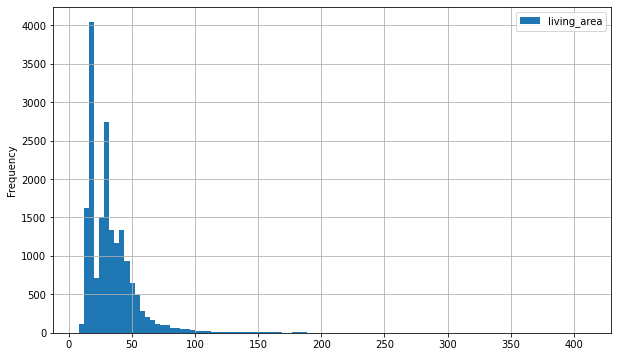

```python
data.plot(y = 'living_area', kind = 'hist', bins = 100, grid=True, figsize = (10,6))
data['living_area'].describe()
```

Хорошо видно, что квартир площадью больше 200 квадратных метров практически нет, но их наличие усложняет чтение графиков. Посмотрим, сколько таких квартир в нашей базе, чтобы понять, можно ли от них избавиться.

```python
data.query('living_area>200').info()
```

```
<class 'pandas.core.frame.DataFrame'>
Int64Index: 22 entries, 511 to 16806
Data columns (total 23 columns):
 #   Column                Non-Null Count  Dtype
---  ------                --------------  -----
 0   total_images          22 non-null     int64
 1   last_price            22 non-null     float64
 2   total_area            22 non-null     float64
 3   first_day_exposition  22 non-null     datetime64[ns]
 4   rooms                 22 non-null     int64
 5   ceiling_height        22 non-null     float64
 6   floors_total          22 non-null     float64
 7   living_area           22 non-null     float64
 8   floor                 22 non-null     int64
 9   is_apartment          22 non-null     bool
 10  studio                22 non-null     bool
 11  open_plan             22 non-null     bool
 12  kitchen_area          22 non-null     float64
 13  balcony               22 non-null     float64
 14  locality_name         22 non-null     object
 15  airports_nearest      22 non-null     float64
 16  city_centers_nearest  22 non-null     float64
 17  parks_around3000      22 non-null     float64
 18  parks_nearest         22 non-null     float64
 19  ponds_around3000      22 non-null     float64
 20  ponds_nearest         22 non-null     float64
 21  days_exposition       22 non-null     float64
 22  locality_only_name    22 non-null     object
dtypes: bool(3), datetime64[ns](1), float64(14), int64(3), object(2)
memory usage: 3.7+ KB
```

22 квартиры, примерно 0,1% от общего количества, пожертвуем ими, чтобы облегчить чтение графиков.

```python
data.loc[data['living_area'] > 200, 'living_area'] =  None
data=data.dropna(subset=['living_area'])
data = data.reset_index(drop=True)
```

Теперь посмотрим на общую площадь.

|  | total_images | last_price | total_area | rooms | ceiling_height | floors_total | living_area | floor | kitchen_area | balcony | airports_nearest | city_centers_nearest | parks_around3000 | parks_nearest | ponds_around3000 | ponds_nearest | days_exposition |
| --- | --- | --- | --- | --- | --- | --- | --- | --- | --- | --- | --- | --- | --- | --- | --- | --- | --- |
| count | 46.000000 | 4.600000e+01 | 46.000000 | 46.000000 | 46.000000 | 46.000000 | 46.000000 | 46.000000 | 46.000000 | 46.000000 | 46.000000 | 46.000000 | 46.000000 | 46.000000 | 46.000000 | 46.000000 | 46.000000 |
| mean | 12.891304 | 5.703546e+07 | 295.468478 | 5.847826 | 2.902391 | 6.260870 | 159.585435 | 5.065217 | 30.610000 | 0.217391 | 27076.217391 | 8293.282609 | 1.173913 | 455.760870 | 1.347826 | 426.163043 | 308.260870 |
| std | 6.973691 | 4.996808e+07 | 39.135456 | 2.139235 | 0.325195 | 4.122754 | 33.387264 | 4.249979 | 16.387528 | 0.467287 | 8529.256005 | 7529.149082 | 1.198227 | 266.526729 | 1.119869 | 211.837308 | 320.000794 |
| min | 0.000000 | 1.250000e+07 | 250.200000 | 3.000000 | 2.650000 | 2.000000 | 74.200000 | 1.000000 | 10.000000 | 0.000000 | 10328.000000 | 436.000000 | 0.000000 | 75.000000 | 0.000000 | 40.000000 | 8.000000 |
| 25% | 7.250000 | 2.762500e+07 | 267.775000 | 5.000000 | 2.650000 | 4.000000 | 139.800000 | 2.000000 | 21.000000 | 0.000000 | 21882.500000 | 4388.000000 | 0.000000 | 364.000000 | 0.000000 | 230.500000 | 90.000000 |
| 50% | 13.500000 | 3.795000e+07 | 287.750000 | 5.500000 | 2.650000 | 5.000000 | 176.600000 | 4.000000 | 28.150000 | 0.000000 | 25410.500000 | 5551.500000 | 1.000000 | 459.000000 | 1.000000 | 491.750000 | 210.000000 |
| 75% | 20.000000 | 6.712500e+07 | 311.425000 | 6.000000 | 3.000000 | 7.000000 | 184.600000 | 5.750000 | 36.750000 | 0.000000 | 30343.750000 | 9458.500000 | 2.000000 | 468.000000 | 2.000000 | 510.000000 | 388.250000 |
| max | 25.000000 | 2.450000e+08 | 413.500000 | 16.000000 | 3.820000 | 20.000000 | 200.000000 | 18.000000 | 100.700000 | 2.000000 | 53531.000000 | 34132.000000 | 3.000000 | 1809.000000 | 3.000000 | 853.000000 | 1365.000000 |

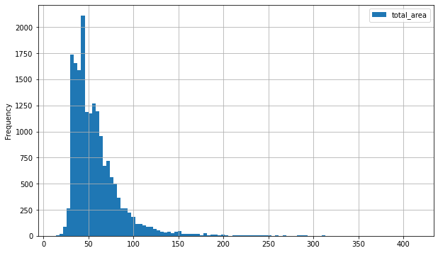

```python
data.plot(y = 'total_area', kind = 'hist', bins = 100, grid=True, figsize = (10,6))
data.query('total_area>250').describe()
```

Поступаем аналагично жилой площади:

```python
data.query('total_area>250').info()
```

```
<class 'pandas.core.frame.DataFrame'>
Int64Index: 46 entries, 926 to 17567
Data columns (total 23 columns):
 #   Column                Non-Null Count  Dtype
---  ------                --------------  -----
 0   total_images          46 non-null     int64
 1   last_price            46 non-null     float64
 2   total_area            46 non-null     float64
 3   first_day_exposition  46 non-null     datetime64[ns]
 4   rooms                 46 non-null     int64
 5   ceiling_height        46 non-null     float64
 6   floors_total          46 non-null     float64
 7   living_area           46 non-null     float64
 8   floor                 46 non-null     int64
 9   is_apartment          46 non-null     bool
 10  studio                46 non-null     bool
 11  open_plan             46 non-null     bool
 12  kitchen_area          46 non-null     float64
 13  balcony               46 non-null     float64
 14  locality_name         46 non-null     object
 15  airports_nearest      46 non-null     float64
 16  city_centers_nearest  46 non-null     float64
 17  parks_around3000      46 non-null     float64
 18  parks_nearest         46 non-null     float64
 19  ponds_around3000      46 non-null     float64
 20  ponds_nearest         46 non-null     float64
 21  days_exposition       46 non-null     float64
 22  locality_only_name    46 non-null     object
dtypes: bool(3), datetime64[ns](1), float64(14), int64(3), object(2)
memory usage: 7.7+ KB
```

```python
data.loc[data['total_area'] > 250, 'total_area'] =  None
data=data.dropna(subset=['total_area'])
data = data.reset_index(drop=True)
data['total_area'].describe()
```

```
count    18051.00000
mean        57.72848
std         27.22872
min         14.00000
25%         40.00000
50%         50.90000
75%         67.50000
max        250.00000
Name: total_area, dtype: float64
```

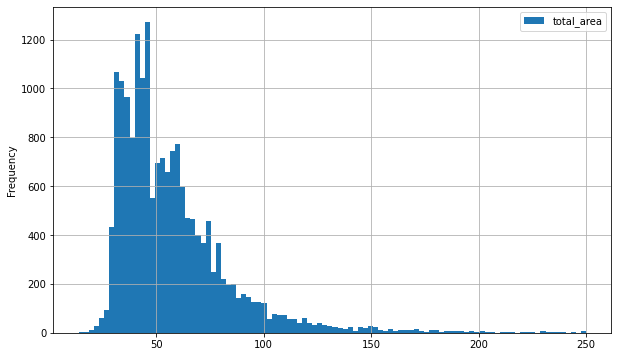

```python
data.plot(y = 'total_area', kind = 'hist', bins = 100, grid=True, figsize = (10,6))
```

Проделываем те же шаги, что и для общей и жилой площади, в отношении площади кухни:

```
<class 'pandas.core.frame.DataFrame'>
Int64Index: 38 entries, 42 to 17500
Data columns (total 23 columns):
 #   Column                Non-Null Count  Dtype
---  ------                --------------  -----
 0   total_images          38 non-null     int64
 1   last_price            38 non-null     float64
 2   total_area            38 non-null     float64
 3   first_day_exposition  38 non-null     datetime64[ns]
 4   rooms                 38 non-null     int64
 5   ceiling_height        38 non-null     float64
 6   floors_total          38 non-null     float64
 7   living_area           38 non-null     float64
 8   floor                 38 non-null     int64
 9   is_apartment          38 non-null     bool
 10  studio                38 non-null     bool
 11  open_plan             38 non-null     bool
 12  kitchen_area          38 non-null     float64
 13  balcony               38 non-null     float64
 14  locality_name         38 non-null     object
 15  airports_nearest      38 non-null     float64
 16  city_centers_nearest  38 non-null     float64
 17  parks_around3000      38 non-null     float64
 18  parks_nearest         38 non-null     float64
 19  ponds_around3000      38 non-null     float64
 20  ponds_nearest         38 non-null     float64
 21  days_exposition       38 non-null     float64
 22  locality_only_name    38 non-null     object
dtypes: bool(3), datetime64[ns](1), float64(14), int64(3), object(2)
memory usage: 6.3+ KB
```

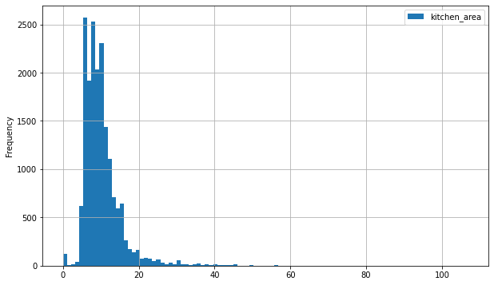

```python
data.plot(y = 'kitchen_area', kind = 'hist', bins = 100, grid=True, figsize = (10,6))
data.query('kitchen_area>45').info()
```

Также избавляемся от редких значений.

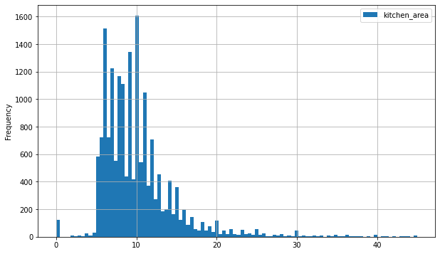

```python
data.loc[data['kitchen_area'] > 45, 'kitchen_area'] =  None
data=data.dropna(subset=['kitchen_area'])
data = data.reset_index(drop=True)
data['kitchen_area'].describe()
data.plot(y = 'kitchen_area', kind = 'hist', bins = 100, grid=True, figsize = (10,6))
```

Касательно высоты домов в СПб:

Болотистая местность и сильные ветра не позволяют строить высокие здания на территории Лен. области. Самый высокий жилой дом Петербурга – 37 этажей. Оценим, сколько в нашей базе домов с бОльшим количеством этажей:

```python
data.query('floors_total>37')
```

|  | total_images | last_price | total_area | first_day_exposition | rooms | ceiling_height | floors_total | living_area | floor | is_apartment | studio | open_plan | kitchen_area | balcony | locality_name | airports_nearest | city_centers_nearest | parks_around3000 | parks_nearest | ponds_around3000 | ponds_nearest | days_exposition | locality_only_name |
| --- | --- | --- | --- | --- | --- | --- | --- | --- | --- | --- | --- | --- | --- | --- | --- | --- | --- | --- | --- | --- | --- | --- | --- |
| 1710 | 12 | 3800000.0 | 45.5 | 2018-06-28 | 2 | 2.88 | 60.0 | 27.4 | 4 | False | False | False | 7.4 | 0.0 | Кронштадт | 67763.0 | 49488.0 | 2.0 | 342.0 | 3.0 | 614.0 | 166.0 | Кронштадт |
| 12757 | 9 | 3978000.0 | 40.0 | 2018-09-24 | 1 | 2.65 | 52.0 | 10.5 | 18 | False | False | False | 14.0 | 0.0 | Санкт-Петербург | 20728.0 | 12978.0 | 1.0 | 793.0 | 0.0 | 510.0 | 45.0 | Санкт-Петербург |

Смело убираем, таких значений у нас всего 2, а 60 этажный дом в Кронштадте и 52 этажный дом в Петербурге упали бы еще на этапе постройки.

```python
data.loc[data['floors_total'] > 37, 'floors_total'] =  None
data=data.dropna(subset=['floors_total']).reset_index()
```

Осталось выбрать, какое максимальное количество комнат стоит оставлять для анализа:

```python
data.query('rooms>6')
```

|  | index | total_images | last_price | total_area | first_day_exposition | rooms | ceiling_height | floors_total | living_area | floor | is_apartment | studio | open_plan | kitchen_area | balcony | locality_name | airports_nearest | city_centers_nearest | parks_around3000 | parks_nearest | ponds_around3000 | ponds_nearest | days_exposition | locality_only_name |
| --- | --- | --- | --- | --- | --- | --- | --- | --- | --- | --- | --- | --- | --- | --- | --- | --- | --- | --- | --- | --- | --- | --- | --- | --- |
| 581 | 581 | 9 | 29500000.0 | 188.8 | 2017-03-04 | 7 | 2.70 | 2.0 | 119.3 | 1 | False | False | False | 10.2 | 0.0 | Санкт-Петербург | 20965.0 | 814.0 | 0.0 | 459.0 | 2.0 | 267.0 | 246.0 | Санкт-Петербург |
| 628 | 628 | 7 | 16500000.0 | 229.0 | 2016-02-25 | 8 | 2.65 | 6.0 | 160.0 | 5 | False | False | False | 25.0 | 0.0 | Санкт-Петербург | 23968.0 | 4536.0 | 1.0 | 243.0 | 0.0 | 510.0 | 806.0 | Санкт-Петербург |
| 663 | 663 | 18 | 15000000.0 | 134.0 | 2017-10-27 | 7 | 2.65 | 4.0 | 88.0 | 3 | False | False | False | 12.0 | 0.0 | Санкт-Петербург | 22670.0 | 3936.0 | 1.0 | 803.0 | 1.0 | 387.0 | 150.0 | Санкт-Петербург |
| 1382 | 1382 | 0 | 15000000.0 | 179.0 | 2017-04-09 | 7 | 2.65 | 5.0 | 126.4 | 5 | False | False | False | 20.9 | 0.0 | Санкт-Петербург | 20070.0 | 3186.0 | 1.0 | 104.0 | 1.0 | 803.0 | 15.0 | Санкт-Петербург |
| 1476 | 1476 | 20 | 16000000.0 | 184.4 | 2018-10-21 | 7 | 2.65 | 6.0 | 125.7 | 5 | False | False | False | 23.1 | 0.0 | Санкт-Петербург | 23382.0 | 2923.0 | 1.0 | 525.0 | 1.0 | 791.0 | 109.0 | Санкт-Петербург |
| 2032 | 2033 | 11 | 16600000.0 | 214.0 | 2017-05-11 | 7 | 3.20 | 5.0 | 131.0 | 4 | False | False | False | 14.4 | 0.0 | Санкт-Петербург | 24542.0 | 4761.0 | 2.0 | 669.0 | 0.0 | 510.0 | 173.0 | Санкт-Петербург |
| 2549 | 2550 | 13 | 22190000.0 | 197.0 | 2017-11-20 | 7 | 2.90 | 6.0 | 107.6 | 1 | False | False | False | 5.0 | 0.0 | Санкт-Петербург | 21583.0 | 1211.0 | 1.0 | 437.0 | 2.0 | 22.0 | 130.0 | Санкт-Петербург |
| 2696 | 2697 | 6 | 13700000.0 | 154.4 | 2017-02-02 | 7 | 3.70 | 5.0 | 117.4 | 5 | False | False | False | 17.4 | 0.0 | Санкт-Петербург | 25881.0 | 4456.0 | 1.0 | 480.0 | 0.0 | 510.0 | 727.0 | Санкт-Петербург |
| 3351 | 3352 | 13 | 22190000.0 | 191.2 | 2017-12-05 | 8 | 2.90 | 6.0 | 115.8 | 1 | False | False | False | 5.0 | 0.0 | Санкт-Петербург | 21589.0 | 1152.0 | 1.0 | 587.0 | 2.0 | 155.0 | 115.0 | Санкт-Петербург |
| 4135 | 4136 | 5 | 16800000.0 | 202.0 | 2017-11-02 | 7 | 3.70 | 5.0 | 145.0 | 4 | False | False | False | 20.0 | 1.0 | Санкт-Петербург | 27035.0 | 5738.0 | 2.0 | 467.0 | 2.0 | 429.0 | 268.0 | Санкт-Петербург |
| 4282 | 4283 | 6 | 27500000.0 | 201.0 | 2017-08-04 | 7 | 3.20 | 5.0 | 130.0 | 2 | False | False | False | 17.0 | 0.0 | Санкт-Петербург | 24383.0 | 5647.0 | 1.0 | 612.0 | 0.0 | 510.0 | 232.0 | Санкт-Петербург |
| 4902 | 4903 | 20 | 82000000.0 | 235.0 | 2017-07-10 | 7 | 3.33 | 7.0 | 147.2 | 5 | False | False | False | 28.4 | 0.0 | Санкт-Петербург | 22992.0 | 1280.0 | 3.0 | 395.0 | 3.0 | 170.0 | 197.0 | Санкт-Петербург |
| 5885 | 5886 | 20 | 16000000.0 | 248.0 | 2017-07-25 | 7 | 3.32 | 6.0 | 166.7 | 2 | False | False | False | 25.3 | 0.0 | Санкт-Петербург | 20074.0 | 3147.0 | 2.0 | 575.0 | 3.0 | 56.0 | 9.0 | Санкт-Петербург |
| 7395 | 7396 | 8 | 33000000.0 | 194.1 | 2017-02-07 | 11 | 3.43 | 5.0 | 129.0 | 2 | False | False | False | 11.9 | 0.0 | Санкт-Петербург | 21469.0 | 1015.0 | 1.0 | 686.0 | 2.0 | 66.0 | 813.0 | Санкт-Петербург |
| 7548 | 7549 | 1 | 12990000.0 | 191.0 | 2017-08-31 | 7 | 3.30 | 5.0 | 136.1 | 2 | False | False | False | 16.0 | 0.0 | Санкт-Петербург | 26856.0 | 5704.0 | 0.0 | 459.0 | 1.0 | 1017.0 | 77.0 | Санкт-Петербург |
| 9490 | 9491 | 8 | 19900000.0 | 210.3 | 2016-04-18 | 8 | 3.30 | 5.0 | 144.6 | 2 | False | False | False | 23.6 | 0.0 | Санкт-Петербург | 24770.0 | 5864.0 | 2.0 | 283.0 | 0.0 | 510.0 | 102.0 | Санкт-Петербург |
| 9807 | 9808 | 9 | 23000000.0 | 226.0 | 2017-04-29 | 7 | 3.50 | 4.0 | 162.0 | 4 | False | False | False | 27.0 | 1.0 | Санкт-Петербург | 24151.0 | 4719.0 | 1.0 | 452.0 | 0.0 | 510.0 | 464.0 | Санкт-Петербург |
| 12317 | 12318 | 5 | 18000000.0 | 225.0 | 2017-06-28 | 7 | 3.33 | 4.0 | 160.0 | 4 | False | False | False | 16.0 | 0.0 | Санкт-Петербург | 24998.0 | 5682.0 | 0.0 | 459.0 | 0.0 | 510.0 | 131.0 | Санкт-Петербург |
| 13119 | 13121 | 2 | 35300000.0 | 235.0 | 2018-11-15 | 8 | 4.00 | 4.0 | 162.0 | 3 | False | False | False | 26.0 | 0.0 | Санкт-Петербург | 19728.0 | 1799.0 | 3.0 | 123.0 | 3.0 | 50.0 | 7.0 | Санкт-Петербург |
| 13235 | 13237 | 18 | 25000000.0 | 134.0 | 2016-12-01 | 7 | 3.29 | 6.0 | 104.0 | 2 | False | False | False | 11.2 | 0.0 | Санкт-Петербург | 25257.0 | 6060.0 | 1.0 | 761.0 | 1.0 | 584.0 | 278.0 | Санкт-Петербург |
| 13714 | 13716 | 19 | 12000000.0 | 125.0 | 2017-02-09 | 7 | 3.30 | 6.0 | 82.0 | 5 | False | False | False | 24.0 | 0.0 | Санкт-Петербург | 24697.0 | 5265.0 | 1.0 | 407.0 | 0.0 | 510.0 | 138.0 | Санкт-Петербург |
| 13802 | 13804 | 4 | 15500000.0 | 216.1 | 2016-07-04 | 10 | 3.15 | 5.0 | 161.4 | 2 | False | False | False | 19.8 | 0.0 | Санкт-Петербург | 24353.0 | 4921.0 | 1.0 | 368.0 | 0.0 | 510.0 | 11.0 | Санкт-Петербург |
| 14425 | 14427 | 4 | 15800000.0 | 236.4 | 2015-02-19 | 8 | 2.65 | 6.0 | 176.6 | 6 | False | False | False | 22.6 | 0.0 | Санкт-Петербург | 20221.0 | 1802.0 | 3.0 | 571.0 | 3.0 | 441.0 | 921.0 | Санкт-Петербург |
| 15838 | 15840 | 6 | 28659000.0 | 245.4 | 2016-03-31 | 14 | 2.65 | 4.0 | 168.3 | 2 | False | False | False | 25.9 | 0.0 | Санкт-Петербург | 21104.0 | 2054.0 | 3.0 | 541.0 | 2.0 | 118.0 | 95.0 | Санкт-Петербург |
| 16926 | 16928 | 20 | 22000000.0 | 141.0 | 2019-01-24 | 7 | 2.65 | 5.0 | 84.0 | 2 | False | False | False | 25.0 | 0.0 | Санкт-Петербург | 20243.0 | 3334.0 | 2.0 | 447.0 | 1.0 | 468.0 | 90.0 | Санкт-Петербург |
| 17209 | 17211 | 18 | 22900000.0 | 206.0 | 2016-04-04 | 7 | 2.65 | 6.0 | 142.0 | 2 | False | False | False | 16.2 | 0.0 | Санкт-Петербург | 25079.0 | 5544.0 | 0.0 | 459.0 | 1.0 | 251.0 | 75.0 | Санкт-Петербург |
| 17788 | 17790 | 17 | 30000000.0 | 213.0 | 2017-09-28 | 7 | 3.40 | 5.0 | 151.4 | 5 | False | False | False | 30.8 | 0.0 | Санкт-Петербург | 21146.0 | 1225.0 | 2.0 | 342.0 | 3.0 | 30.0 | 299.0 | Санкт-Петербург |

Убираем эти данные, т.к. это затруднит чтение графиков

```python
data.loc[data['rooms'] > 6, 'rooms'] =  None
data=data.dropna(subset=['rooms'])
data = data.reset_index(drop=True)
```

### Посчитайте и добавьте в таблицу новые столбцы

```python
data['square_meter_price'] = data['last_price']/data['total_area']
```

Столбец с ценой одного квадратного метра

```python
data['weekday'] = data['first_day_exposition'].dt.weekday
data['month'] = data['first_day_exposition'].dt.month
data['year'] = data['first_day_exposition'].dt.year
```

Столбцы с днем недели, месяцем и годом публикации объявления

```python
def floor_type(row):
    floor = row['floor']
    floors_total = row['floors_total']
    if floor == 1.0:
        return 'первый'
    if floor == floors_total:
        return 'последний'
    else:
        return 'другой'
data['floor_type'] = data.apply(floor_type, axis = 1)
```

Столбец с типом этажа квартиры

```python
data['city_centers_nearest'] = (data['city_centers_nearest']/1000).round()
data['city_centers_nearest']
```

```
0        19.0
1        14.0
2         8.0
3        70.0
4        19.0
         ...
17979     6.0
17980     4.0
17981    70.0
17982    34.0
17983    70.0
Name: city_centers_nearest, Length: 17984, dtype: float64
```

Расстояние от центра в километрах оставляем в уже существующем столбце, так как для анализа нам не нужны и расстояние в метрах, и расстояние в километрах.

Исследуем последний параметр, в котором можно найти подозрительные значения: цена за квадратный метр.

```python
data['square_meter_price'].describe()
```

```
count    1.798400e+04
mean     9.706416e+04
std      4.133978e+04
min      1.118349e+02
25%      7.676012e+04
50%      9.400000e+04
75%      1.116667e+05
max      1.736842e+06
Name: square_meter_price, dtype: float64
```

Подозрительное минимальное значение. На разных сайтах по продажам квартир, я смогла найти объявления по продаже квартир в Лен. области по цене около 15 000 рублей за квадратный метр, которые выглядят правдоподобно. Рассмотрим поближе квартиры с более низкой ценой.

```python
data['city_centers_nearest'].describe()
```

```
count    17984.000000
mean        26.401857
std         24.085349
min          0.000000
25%         11.000000
50%         15.000000
75%         33.000000
max         70.000000
Name: city_centers_nearest, dtype: float64
```

```python
data.query('square_meter_price<15000')
```

|  | index | total_images | last_price | total_area | first_day_exposition | rooms | ceiling_height | floors_total | living_area | floor | is_apartment | studio | open_plan | kitchen_area | balcony | locality_name | airports_nearest | city_centers_nearest | parks_around3000 | parks_nearest | ponds_around3000 | ponds_nearest | days_exposition | locality_only_name | square_meter_price | weekday | month | year | floor_type |
| --- | --- | --- | --- | --- | --- | --- | --- | --- | --- | --- | --- | --- | --- | --- | --- | --- | --- | --- | --- | --- | --- | --- | --- | --- | --- | --- | --- | --- | --- |
| 200 | 200 | 7 | 650000.0 | 46.0 | 2018-03-15 | 2.0 | 2.50 | 5.0 | 30.0 | 5 | False | False | False | 7.0 | 0.0 | Сланцы | 200000.0 | 70.0 | 0.0 | 3100.0 | 0.0 | 3100.0 | 75.0 | Сланцы | 14130.434783 | 3 | 3 | 2018 | последний |
| 2309 | 2316 | 20 | 900000.0 | 61.4 | 2018-02-03 | 3.0 | 2.70 | 2.0 | 40.0 | 2 | False | False | False | 9.5 | 0.0 | Подпорожье | 200000.0 | 70.0 | 0.0 | 3100.0 | 0.0 | 3100.0 | 363.0 | Подпорожье | 14657.980456 | 5 | 2 | 2018 | последний |
| 3109 | 3118 | 9 | 790000.0 | 61.0 | 2018-04-02 | 3.0 | 2.65 | 2.0 | 48.0 | 2 | False | False | False | 12.0 | 0.0 | Луга | 200000.0 | 70.0 | 0.0 | 3100.0 | 0.0 | 3100.0 | 350.0 | Луга | 12950.819672 | 0 | 4 | 2018 | последний |
| 3325 | 3334 | 9 | 500000.0 | 52.0 | 2018-08-02 | 2.0 | 2.70 | 2.0 | 31.0 | 1 | False | False | False | 8.0 | 0.0 | Сланцы | 200000.0 | 70.0 | 0.0 | 3100.0 | 0.0 | 3100.0 | 110.0 | Сланцы | 9615.384615 | 3 | 8 | 2018 | первый |
| 3540 | 3550 | 11 | 950000.0 | 66.6 | 2017-10-26 | 3.0 | 2.65 | 4.0 | 43.4 | 1 | False | False | False | 9.4 | 0.0 | поселок Житково | 200000.0 | 70.0 | 0.0 | 3100.0 | 0.0 | 3100.0 | 89.0 | Житково | 14264.264264 | 3 | 10 | 2017 | первый |
| 3817 | 3827 | 6 | 900000.0 | 62.0 | 2016-04-03 | 3.0 | 2.65 | 5.0 | 35.0 | 1 | False | False | False | 6.0 | 0.0 | Сланцы | 200000.0 | 70.0 | 0.0 | 3100.0 | 0.0 | 3100.0 | 531.0 | Сланцы | 14516.129032 | 6 | 4 | 2016 | первый |
| 4311 | 4323 | 7 | 450000.0 | 42.0 | 2017-07-31 | 2.0 | 2.65 | 1.0 | 23.0 | 1 | False | False | False | 5.8 | 0.0 | городской посёлок Будогощь | 200000.0 | 70.0 | 0.0 | 3100.0 | 0.0 | 3100.0 | 233.0 | Будогощь | 10714.285714 | 0 | 7 | 2017 | первый |
| 5758 | 5771 | 4 | 850000.0 | 58.8 | 2017-09-27 | 2.0 | 2.65 | 3.0 | 47.0 | 1 | False | False | False | 8.5 | 0.0 | Сланцы | 200000.0 | 70.0 | 0.0 | 3100.0 | 0.0 | 3100.0 | 45.0 | Сланцы | 14455.782313 | 2 | 9 | 2017 | первый |
| 6675 | 6689 | 6 | 650000.0 | 45.0 | 2017-06-24 | 2.0 | 2.65 | 5.0 | 30.0 | 1 | False | False | False | 6.0 | 0.0 | Бокситогорск | 200000.0 | 70.0 | 0.0 | 3100.0 | 0.0 | 3100.0 | 68.0 | Бокситогорск | 14444.444444 | 5 | 6 | 2017 | первый |
| 6695 | 6709 | 7 | 12190.0 | 109.0 | 2019-03-20 | 2.0 | 2.75 | 25.0 | 32.0 | 25 | False | False | False | 40.5 | 0.0 | Санкт-Петербург | 36421.0 | 9.0 | 1.0 | 805.0 | 0.0 | 510.0 | 8.0 | Санкт-Петербург | 111.834862 | 2 | 3 | 2019 | последний |
| 7220 | 7234 | 4 | 850000.0 | 78.0 | 2017-05-04 | 3.0 | 2.65 | 9.0 | 12.5 | 7 | False | False | False | 8.5 | 0.0 | Гатчина | 200000.0 | 70.0 | 0.0 | 3100.0 | 0.0 | 3100.0 | 169.0 | Гатчина | 10897.435897 | 3 | 5 | 2017 | другой |
| 7307 | 7321 | 7 | 450000.0 | 43.4 | 2018-08-31 | 2.0 | 2.65 | 5.0 | 30.3 | 3 | False | False | False | 5.5 | 0.0 | деревня Старополье | 200000.0 | 70.0 | 0.0 | 3100.0 | 0.0 | 3100.0 | 96.0 | Старополье | 10368.663594 | 4 | 8 | 2018 | другой |
| 7955 | 7971 | 5 | 850000.0 | 67.0 | 2017-12-02 | 3.0 | 2.65 | 5.0 | 41.0 | 3 | False | False | False | 7.4 | 2.0 | поселок городского типа Ефимовский | 200000.0 | 70.0 | 0.0 | 3100.0 | 0.0 | 3100.0 | 146.0 | Ефимовский | 12686.567164 | 5 | 12 | 2017 | другой |
| 8066 | 8082 | 0 | 730000.0 | 63.0 | 2016-05-16 | 3.0 | 2.65 | 2.0 | 43.0 | 1 | False | False | False | 6.0 | 0.0 | Сланцы | 200000.0 | 70.0 | 0.0 | 3100.0 | 0.0 | 3100.0 | 45.0 | Сланцы | 11587.301587 | 0 | 5 | 2016 | первый |
| 8534 | 8550 | 2 | 600000.0 | 45.1 | 2018-11-09 | 2.0 | 2.50 | 5.0 | 27.9 | 4 | False | False | False | 5.4 | 1.0 | деревня Фалилеево | 200000.0 | 70.0 | 0.0 | 3100.0 | 0.0 | 3100.0 | 128.0 | Фалилеево | 13303.769401 | 4 | 11 | 2018 | другой |
| 8635 | 8651 | 17 | 550000.0 | 54.0 | 2019-02-07 | 2.0 | 3.00 | 2.0 | 40.0 | 1 | False | False | False | 7.5 | 0.0 | Сланцы | 200000.0 | 70.0 | 0.0 | 3100.0 | 0.0 | 3100.0 | 78.0 | Сланцы | 10185.185185 | 3 | 2 | 2019 | первый |
| 8864 | 8880 | 9 | 750000.0 | 58.0 | 2016-03-18 | 2.0 | 2.65 | 2.0 | 36.0 | 2 | False | False | False | 9.0 | 0.0 | поселок Тёсово-4 | 200000.0 | 70.0 | 0.0 | 3100.0 | 0.0 | 3100.0 | 181.0 | Тёсово-4 | 12931.034483 | 4 | 3 | 2016 | последний |
| 9052 | 9068 | 10 | 880000.0 | 60.0 | 2017-09-24 | 3.0 | 2.65 | 5.0 | 42.0 | 1 | False | False | False | 6.0 | 0.0 | Сланцы | 200000.0 | 70.0 | 0.0 | 3100.0 | 0.0 | 3100.0 | 59.0 | Сланцы | 14666.666667 | 6 | 9 | 2017 | первый |
| 10520 | 10538 | 6 | 565000.0 | 45.0 | 2017-09-28 | 2.0 | 2.60 | 3.0 | 25.0 | 1 | False | False | False | 9.0 | 2.0 | поселок Совхозный | 200000.0 | 70.0 | 0.0 | 3100.0 | 0.0 | 3100.0 | 161.0 | Совхозный | 12555.555556 | 3 | 9 | 2017 | первый |
| 10884 | 10902 | 4 | 500000.0 | 34.0 | 2016-02-09 | 1.0 | 2.65 | 5.0 | 17.0 | 4 | False | False | False | 8.0 | 1.0 | поселок городского типа Никольский | 200000.0 | 70.0 | 0.0 | 3100.0 | 0.0 | 3100.0 | 724.0 | Никольский | 14705.882353 | 1 | 2 | 2016 | другой |
| 12033 | 12051 | 14 | 700000.0 | 53.0 | 2017-08-29 | 2.0 | 2.65 | 2.0 | 36.0 | 2 | False | False | False | 6.5 | 0.0 | Пикалёво | 200000.0 | 70.0 | 0.0 | 3100.0 | 0.0 | 3100.0 | 12.0 | Пикалёво | 13207.547170 | 1 | 8 | 2017 | последний |
| 12761 | 12781 | 11 | 1000000.0 | 69.0 | 2018-08-26 | 3.0 | 2.65 | 5.0 | 54.0 | 2 | False | False | False | 7.0 | 0.0 | Сланцы | 200000.0 | 70.0 | 0.0 | 3100.0 | 0.0 | 3100.0 | 45.0 | Сланцы | 14492.753623 | 6 | 8 | 2018 | другой |
| 13452 | 13474 | 0 | 450000.0 | 36.5 | 2018-02-01 | 1.0 | 2.65 | 5.0 | 17.3 | 4 | False | False | False | 8.5 | 1.0 | деревня Ям-Тесово | 200000.0 | 70.0 | 0.0 | 3100.0 | 0.0 | 3100.0 | 120.0 | Ям-Тесово | 12328.767123 | 3 | 2 | 2018 | другой |
| 14345 | 14369 | 1 | 470000.0 | 41.0 | 2018-02-11 | 1.0 | 2.65 | 5.0 | 32.0 | 3 | False | False | False | 9.0 | 0.0 | деревня Выскатка | 200000.0 | 70.0 | 0.0 | 3100.0 | 0.0 | 3100.0 | 46.0 | Выскатка | 11463.414634 | 6 | 2 | 2018 | другой |
| 14798 | 14823 | 13 | 560000.0 | 52.0 | 2017-11-21 | 2.0 | 3.00 | 3.0 | 30.0 | 3 | False | False | False | 6.0 | 0.0 | Сланцы | 200000.0 | 70.0 | 0.0 | 3100.0 | 0.0 | 3100.0 | 207.0 | Сланцы | 10769.230769 | 1 | 11 | 2017 | последний |
| 14822 | 14847 | 8 | 1200000.0 | 89.0 | 2017-07-08 | 4.0 | 3.00 | 2.0 | 60.3 | 2 | False | False | False | 10.0 | 0.0 | Сланцы | 200000.0 | 70.0 | 0.0 | 3100.0 | 0.0 | 3100.0 | 242.0 | Сланцы | 13483.146067 | 5 | 7 | 2017 | последний |
| 15142 | 15167 | 2 | 700000.0 | 53.0 | 2017-11-16 | 2.0 | 2.65 | 5.0 | 30.4 | 1 | False | False | False | 8.4 | 2.0 | деревня Выскатка | 200000.0 | 70.0 | 0.0 | 3100.0 | 0.0 | 3100.0 | 45.0 | Выскатка | 13207.547170 | 3 | 11 | 2017 | первый |
| 15383 | 15408 | 14 | 850000.0 | 63.0 | 2017-12-19 | 3.0 | 2.50 | 5.0 | 42.0 | 1 | False | False | False | 6.0 | 0.0 | Сланцы | 200000.0 | 70.0 | 0.0 | 3100.0 | 0.0 | 3100.0 | 175.0 | Сланцы | 13492.063492 | 1 | 12 | 2017 | первый |
| 15526 | 15551 | 6 | 600000.0 | 42.0 | 2017-10-13 | 2.0 | 2.65 | 5.0 | 31.0 | 5 | False | False | False | 6.0 | 1.0 | Сланцы | 200000.0 | 70.0 | 0.0 | 3100.0 | 0.0 | 3100.0 | 29.0 | Сланцы | 14285.714286 | 4 | 10 | 2017 | последний |
| 16835 | 16861 | 9 | 850000.0 | 66.8 | 2018-11-13 | 3.0 | 2.65 | 5.0 | 57.4 | 2 | False | False | False | 9.0 | 2.0 | деревня Малая Романовка | 200000.0 | 70.0 | 0.0 | 3100.0 | 0.0 | 3100.0 | 9.0 | Малая Романовка | 12724.550898 | 1 | 11 | 2018 | другой |
| 17111 | 17138 | 0 | 740000.0 | 59.0 | 2015-07-18 | 2.0 | 2.65 | 3.0 | 38.0 | 3 | False | False | False | 8.5 | 0.0 | Сланцы | 200000.0 | 70.0 | 0.0 | 3100.0 | 0.0 | 3100.0 | 847.0 | Сланцы | 12542.372881 | 5 | 7 | 2015 | последний |
| 17820 | 17849 | 3 | 1450000.0 | 138.0 | 2018-07-06 | 3.0 | 2.65 | 2.0 | 58.0 | 2 | False | False | False | 12.0 | 0.0 | Гатчина | 200000.0 | 70.0 | 0.0 | 3100.0 | 0.0 | 3100.0 | 52.0 | Гатчина | 10507.246377 | 4 | 7 | 2018 | последний |
| 17827 | 17856 | 11 | 470000.0 | 44.5 | 2018-07-02 | 2.0 | 2.65 | 2.0 | 28.0 | 2 | False | False | False | 7.5 | 0.0 | Сланцы | 200000.0 | 70.0 | 0.0 | 3100.0 | 0.0 | 3100.0 | 298.0 | Сланцы | 10561.797753 | 0 | 7 | 2018 | последний |

```python
data.loc[data['square_meter_price'] < 10000, 'kitchen_area'] =  None
data=data.dropna(subset=['kitchen_area'])
data = data.reset_index(drop=True)
```

```
<class 'pandas.core.frame.DataFrame'>
RangeIndex: 17982 entries, 0 to 17981
Data columns (total 29 columns):
 #   Column                Non-Null Count  Dtype
---  ------                --------------  -----
 0   index                 17982 non-null  int64
 1   total_images          17982 non-null  int64
 2   last_price            17982 non-null  float64
 3   total_area            17982 non-null  float64
 4   first_day_exposition  17982 non-null  datetime64[ns]
 5   rooms                 17982 non-null  float64
 6   ceiling_height        17982 non-null  float64
 7   floors_total          17982 non-null  float64
 8   living_area           17982 non-null  float64
 9   floor                 17982 non-null  int64
```

[output cut: 21 more lines]

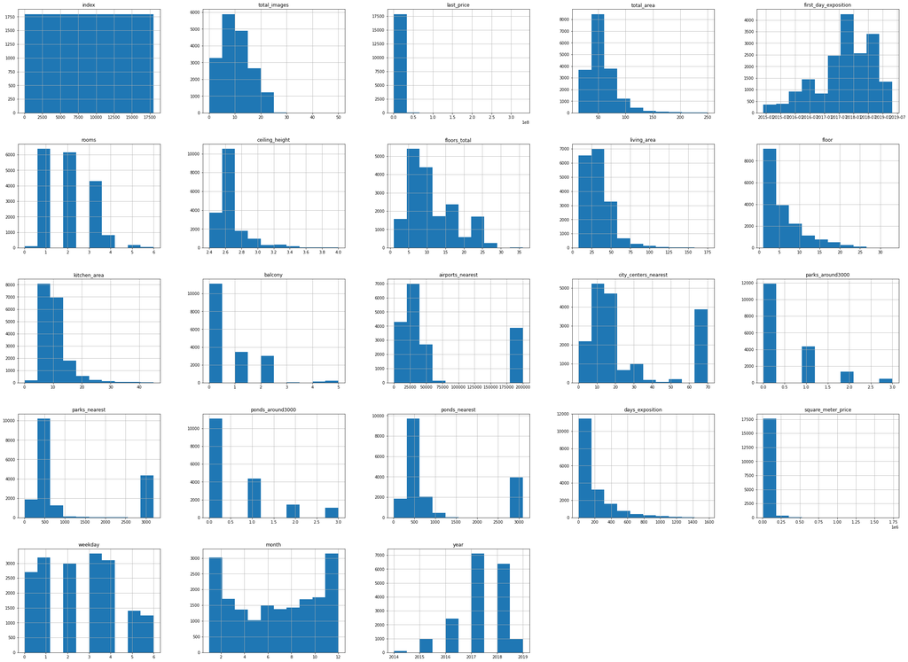

```python
data.info()
data.hist(figsize = (40, 30))
None
```

Данные подготовлены к анализу, можно приступать к изучению отдельных параметров.

### Проведите исследовательский анализ данных

#### Параметры объектов

Рассмотрим поближе некоторые параметры, возможно, получится найти больше аномальных значений или какие-то интересные закономерности.

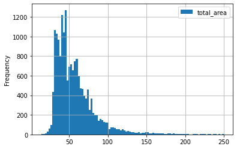

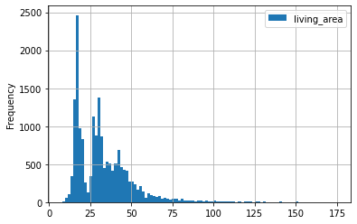

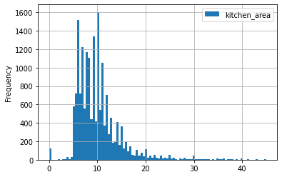

```python
data.plot(y = 'total_area', kind = 'hist', bins = 100, grid=True, figsize = (6,4))
data.plot(y = 'living_area', kind = 'hist', bins = 100, grid=True, figsize = (6,4))
data.plot(y = 'kitchen_area', kind = 'hist', bins = 100, grid=True, figsize = (6, 4))
```

Для общей и жилой площади отчетливо видны "ямы" сразу после наиболее распространенных значений. Можно предположить, что это "граница" между стандартными квартирами и квартирами в историческом центре, т.к. такие квартиры зачастую намного больше, чем более новые квартиры. Что касается площади кухни: график неравномерны, но и разброс значений в разы меньше, поэтому нельзя сказать, что он выглядит странно.

|  | index | total_images | last_price | total_area | first_day_exposition | rooms | ceiling_height | floors_total | living_area | floor | is_apartment | studio | open_plan | kitchen_area | balcony | locality_name | airports_nearest | city_centers_nearest | parks_around3000 | parks_nearest | ponds_around3000 | ponds_nearest | days_exposition | locality_only_name | square_meter_price | weekday | month | year | floor_type |
| --- | --- | --- | --- | --- | --- | --- | --- | --- | --- | --- | --- | --- | --- | --- | --- | --- | --- | --- | --- | --- | --- | --- | --- | --- | --- | --- | --- | --- | --- |
| 37 | 37 | 13 | 22000000.0 | 161.8 | 2015-07-08 | 4.0 | 2.80 | 4.0 | 80.90 | 2 | False | False | False | 17.60 | 5.0 | Петергоф | 35416.0 | 31.0 | 2.0 | 47.0 | 1.0 | 907.0 | 987.0 | Петергоф | 135970.333745 | 2 | 7 | 2015 | другой |
| 98 | 98 | 20 | 33000000.0 | 180.0 | 2017-02-17 | 3.0 | 2.90 | 9.0 | 86.00 | 8 | False | False | False | 24.00 | 4.0 | Санкт-Петербург | 25689.0 | 4.0 | 1.0 | 633.0 | 0.0 | 510.0 | 144.0 | Санкт-Петербург | 183333.333333 | 4 | 2 | 2017 | другой |
| 117 | 117 | 10 | 27700000.0 | 179.6 | 2017-07-06 | 5.0 | 2.85 | 25.0 | 97.20 | 25 | False | False | False | 33.80 | 2.0 | Санкт-Петербург | 19424.0 | 4.0 | 0.0 | 459.0 | 1.0 | 806.0 | 75.0 | Санкт-Петербург | 154231.625835 | 3 | 7 | 2017 | последний |
| 136 | 136 | 3 | 21042018.0 | 154.9 | 2017-09-10 | 4.0 | 3.30 | 16.0 | 89.11 | 3 | False | False | False | 21.30 | 0.0 | Санкт-Петербург | 37434.0 | 8.0 | 1.0 | 441.0 | 2.0 | 427.0 | 563.0 | Санкт-Петербург | 135842.595223 | 6 | 9 | 2017 | другой |
| 178 | 178 | 16 | 22000000.0 | 119.0 | 2017-02-16 | 3.0 | 3.50 | 5.0 | 56.00 | 3 | False | False | False | 35.00 | 0.0 | Санкт-Петербург | 21698.0 | 2.0 | 1.0 | 688.0 | 1.0 | 86.0 | 77.0 | Санкт-Петербург | 184873.949580 | 3 | 2 | 2017 | другой |
| ... | ... | ... | ... | ... | ... | ... | ... | ... | ... | ... | ... | ... | ... | ... | ... | ... | ... | ... | ... | ... | ... | ... | ... | ... | ... | ... | ... | ... | ... |
| 17756 | 17786 | 4 | 40000000.0 | 188.0 | 2017-05-29 | 6.0 | 2.65 | 6.0 | 109.51 | 4 | False | False | False | 31.30 | 0.0 | Санкт-Петербург | 23390.0 | 2.0 | 2.0 | 425.0 | 1.0 | 62.0 | 30.0 | Санкт-Петербург | 212765.957447 | 0 | 5 | 2017 | другой |
| 17794 | 17825 | 19 | 27000000.0 | 110.0 | 2016-03-11 | 3.0 | 2.65 | 7.0 | 63.00 | 5 | False | False | False | 15.00 | 1.0 | Санкт-Петербург | 26819.0 | 5.0 | 1.0 | 657.0 | 1.0 | 678.0 | 200.0 | Санкт-Петербург | 245454.545455 | 4 | 3 | 2016 | другой |
| 17831 | 17862 | 20 | 21800000.0 | 250.0 | 2017-09-16 | 3.0 | 2.65 | 12.0 | 104.00 | 7 | False | False | False | 45.00 | 0.0 | Санкт-Петербург | 43558.0 | 13.0 | 0.0 | 459.0 | 0.0 | 510.0 | 49.0 | Санкт-Петербург | 87200.000000 | 5 | 9 | 2017 | другой |
| 17848 | 17879 | 3 | 22529250.0 | 139.5 | 2018-07-04 | 4.0 | 3.30 | 16.0 | 82.55 | 9 | False | False | False | 13.84 | 0.0 | Санкт-Петербург | 37434.0 | 8.0 | 1.0 | 441.0 | 2.0 | 427.0 | 266.0 | Санкт-Петербург | 161500.000000 | 2 | 7 | 2018 | другой |
| 17901 | 17932 | 0 | 21187872.0 | 123.3 | 2017-04-25 | 3.0 | 2.65 | 18.0 | 50.40 | 18 | False | False | False | 23.60 | 0.0 | Санкт-Петербург | 19095.0 | 5.0 | 0.0 | 459.0 | 0.0 | 510.0 | 104.0 | Санкт-Петербург | 171840.000000 | 1 | 4 | 2017 | последний |

320 rows × 29 columns

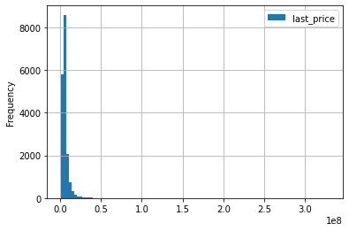

```python
data.plot(y = 'last_price', kind = 'hist', bins = 100, grid=True, figsize = (6,4))

data.query('last_price>20000000')
```

```python
data.loc[data['last_price'] > 30000000, 'last_price'] =  None
data=data.dropna(subset=['last_price'])
```

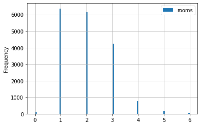

```python
data.plot(y = 'rooms', kind = 'hist', bins = 100, grid=True, figsize = (6,4))
```

Никаких неожиданных результатов, оставляем как есть по той же причине: далее будем исследовать зависимость между количеством комнат и ценой.

Высоту потолков мы уже рассматривали выше, все данные выглядят правдоподобно.

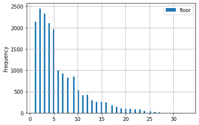

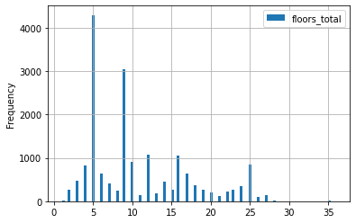

```python
data.plot(y = 'floor', kind = 'hist', bins = 100, grid=True, figsize = (6,4))
data.plot(y = 'floors_total', kind = 'hist', bins = 100, grid=True, figsize = (6,4))
```

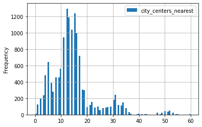

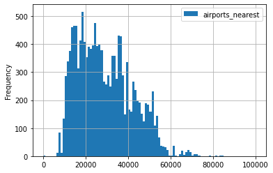

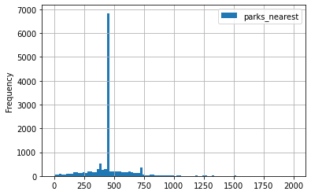

```python
data.plot(y = 'city_centers_nearest', kind = 'hist', bins = 100, grid=True, figsize = (6,4), range=(0, 60))
data.plot(y = 'airports_nearest', kind = 'hist', bins = 100, grid=True, figsize = (6,4), range=(0, 100000))
data.plot(y = 'parks_nearest', kind = 'hist', bins = 100, grid=True, figsize = (6,4), range=(0, 2000))
```

Ограничиваем таблицы, т.к. мы искусственно добавили число немного привышающее максимальное для пропущенных значений. Логично предположить, что в таблицах для расстояния от центра и расстояния от аэропорта, скачки в таблицах появились из-за больших городов в Лен.области, поэтому опять ничего необычного. Касательно расстояния до парка: большой скачок в районе 450 метров. Можно предположить, что связано с большим количеством новостроек в районах с парками.

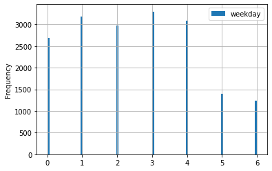

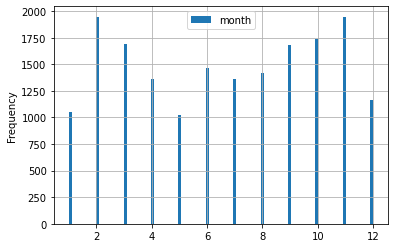

```python
data.plot(y = 'weekday', kind = 'hist', bins = 100, grid=True, figsize = (6,4))
data.plot(y = 'month', kind = 'hist', bins = 100, grid=True, figsize = (6,4))
```

Заметно, что объявления реже выставляют в выходные дни и в месяцы, когда чаще берут отпуск либо в месяцы с длительными государственными праздниками. Скорее всего, это связано с тем, что большинство квартир выставляют риэлторы, которые в выходные занимаются скорее выездами и показами квартир, берут отпуск летом и отдыхают на новогодние и майские праздники.

*Изучим скорось продажи квартир*

```
count    17856.000000
mean       183.414763
std        219.873521
min          1.000000
25%         44.000000
50%        100.000000
75%        235.000000
max       1580.000000
Name: days_exposition, dtype: float64
```

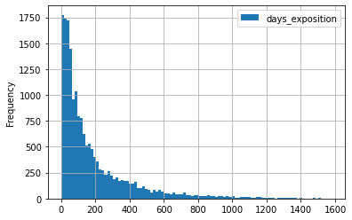

```python
data.plot(y = 'days_exposition', kind = 'hist', bins = 100, grid=True, figsize = (6,4))
data['days_exposition'].describe()
```

Среднее значение почти в 2 раза больше медианного, но это нормально, учитывая, что мы оставили элитные квартиры. Их как раз значительно меньше, но продаваться они будут дольше. Но даже такие квартиры вряд ли будут продаваться больше 2-2,5 лет. Уберем неправдоподобные данные прежде чем строить график размаха.

```python
data.loc[data['days_exposition'] > 800, 'days_exposition'] =  None
data=data.dropna(subset=['days_exposition'])
data = data.reset_index(drop=True)
```

```
count    17338.000000
mean       158.462914
std        165.750356
min          1.000000
25%         43.000000
50%         96.000000
75%        216.000000
max        800.000000
Name: days_exposition, dtype: float64
```

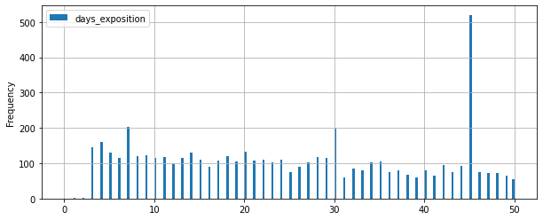

```python
data.plot(y = 'days_exposition', kind = 'hist', bins = 200, grid=True, figsize = (10,4), range=(0, 50))
data['days_exposition'].describe()
```

```
count    17338.000000
mean       158.462914
std        165.750356
min          1.000000
25%         43.000000
50%         96.000000
75%        216.000000
max        800.000000
Name: days_exposition, dtype: float64
```

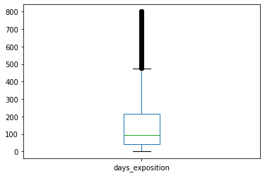

```python
data['days_exposition'].plot.box()
data['days_exposition'].describe()
```

Большинство квартир продаются в среднем примерно за 100 дней. Продажу быстрее, чем за 42 дня можно назвать быстрой. Если же продажа занимает больше 200 дей, ее можно назвать необычайно долгой.

#### Факторы, влияющие на общую стоимость квартиры

Изучим, какие факторы в большей степени влияют на общую стоимость квартиры. Для этого построим графики

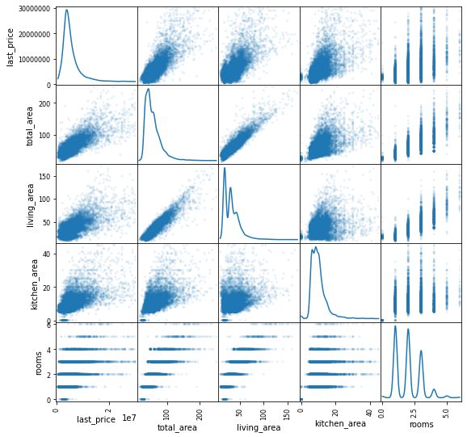

```python
cols = ['last_price', 'total_area', 'living_area', 'kitchen_area', 'rooms']
pd.plotting.scatter_matrix(data[cols], diagonal='kde', figsize=(9, 9), alpha=0.1);
```

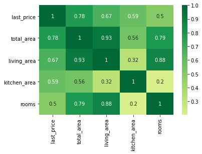

```python
sns.heatmap(data[cols].corr(), xticklabels=data[cols].corr(), yticklabels=data[cols].corr(), cmap='RdYlGn', center=0, annot=True)
```

Можно увидеть, что самая очевидная зависимость прослеживается между общей площадью и ценой, видна довольно сильная положительная линейная корелляция. Точки выстраиваются вокруг линии наилучшего соответствия, что позволяет говорить о прямой зависимости.

Касательно жилой площади и площади кухни, положительная корелляция все еще прослеживается, но уже слабая. В последнем графике так же сильно заметен разрыв в самом начале: бывают квартиры без кухни (например, студии), однако квартир с кухней площадью меньше 4 квадратных метров практически нет, так что диаграмма выглядит реалистично.

Для лучшего понимания, добавим в эти диаграммы еще одно значение: количество комнат.

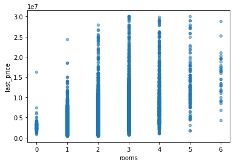

```python
data.plot(x='rooms', y='last_price', kind='scatter', alpha=0.5)
```

В целом прослеживается тенденция "чем больше комнат, тем дороже будет стоить квартира", но цена на студии как будто бы начинается с большего значения, чем цена на одно- и двухкомнатные квартиры.

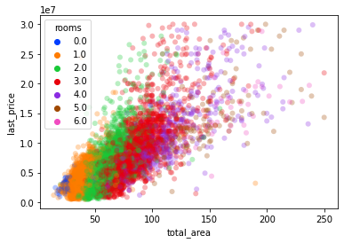

```python
colors = sns.color_palette("bright")[:data.rooms.nunique()]
sns.scatterplot(x="total_area", y="last_price",
hue="rooms",
palette=colors,
linewidth=0, alpha=0.3,
data=data)
```

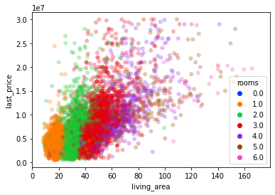

```python
sns.scatterplot(x="living_area", y="last_price",
hue="rooms",
palette=colors,
linewidth=0, alpha=0.3,
data=data)
```

В целом, картина не изменилась, единственное, что можно добавить: видна тенденция "чем больше комнат, тем больше площадь", которая не так актуальна, если комнат больше 4.

Теперь рассмотрим влияние этажа на стоимость объекта:

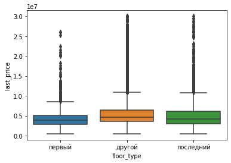

```python
sns.boxplot(x='floor_type', y='last_price', data=data, notch=False)
```

Можно сказать, что квартиры на первом этаже как правило стоят дешевле прочих. Похожая тенденция прослеживается и для квартир на последнем этаже, но она не столь очевидна.